# **Natural Resource Revenues and Governance Outcomes**

## An Empirical Analysis Using EITI and World Bank Data (2015–2023)

[figure not shown]

- [Open the report (HTML)](https://fs-1313.github.io/test_repo/)
- I. Introduction
  - I.1 Background
  - I.2 Research Question and Methodology
- II. Data Sources and Construction
  - II.0 Configuration and Global Setup
  - II.1 World Bank Data (WDI and WGI)
  - II.2 EITI Data
  - II.3 Data Merging
- III. Exploratory Data Analysis
  - III.0 EDA Set-up
  - III.1 Extractive Revenues and Governance Trends Over Time
  - III.2 Governance Trends Across EITI-Implementing Countries
  - III.3 Heterogeneity in Governance Changes Across Countries
  - III.4 Average Governance Levels Across EITI-Implementing Countries
  - III.5 Correlation Structure of Governance Dimensions
  - III.6 Governance Regimes: Clustering Countries by Institutional Quality
  - III.7 Robustness of Governance Regimes: Hierarchical Clustering
  - III.8 Resource Rents and Governance: Cross-Section vs Within-Country Effects
  - III.9 Robustness: Oil, Gas, and Mineral Rents
  - III.10 Robustness: Governance Changes Instead of Levels
  - III.11 Country Case Analysis by Governance Regime
- IV. Conclusion
- V. References

# I. Introduction

## I.1 Background

**In 2015, the Paris Climate Agreement marked a global commitment to reduce greenhouse gas emissions through a transition toward cleaner energy sources such as electric vehicles, solar power, and wind energy.**

One of the agreed upon solutions includes the transition to cleaner forms of energy such as electric vehicles, solar panels, and wind turbines. This creates diverging scenarios for resource-rich countries. Countries rich in energy transition minerals—such as nickel and copper—needed to manufacture renewable technologies are expected to benefit from rising mineral demand. Conversely, those hosting oil and gas resources will see declining government revenues as long-term demand for these resources diminishes.

**The Resource Curse Problem**

Resource-rich countries generate significant revenues from the extraction of their finite resources. These resource revenues could be spent on building roads, hospitals, and schools for the benefit of their citizens. Unfortunately, many resource-rich countries have failed to realize economic benefits from these resources and have instead suffered from lower economic growth, social and military conflicts, and political instability (Sachs & Warner, 1995; Ross, 2012). Economists and political scientists call this phenomenon the resource curse or the paradox of plenty.

**Why Governance Matters**

In an ideal world, resource-rich countries would maximize the benefits from resource extraction through good governance. Governance is the system of policies, processes, and institutional frameworks that defines how governments and stakeholders conduct public affairs, including the management of natural resources. The quality of a country's governance plays a critical role in determining resource extraction outcomes. When rules and systems are transparent, accountable, and responsive, governments are better positioned to address the significant challenges and opportunities of large-scale resource extraction. For instance, when corruption is controlled and government spending is transparent, citizens benefit more from their finite resources. Conversely, when government transactions are opaque and regulation is weak, corruption thrives and resource benefits accrue only to a few elites.

**Theoretical frameworks**

The literature provides theories and models to explain this phenomenon. Acemoglu & Robinson (2012) argue that investments and economic growth are driven by the quality and inclusivity of political and economic institutions. Theoretically, resource-dependent governments—faced by finite resources—are incentivized to invest in policy reforms and institutional building to diversify their economies and generate long-term growth. Following this logic, governance should improve in response to resource dependence and volatility of resource revenues. Alternatively, Krueger (1974) coined the rent-seeking theory, which posits that when significant rents are generated and access to these rents is mediated by the government, political and economic elites are incentivized to engage in rent-seeking behavior such as lobbying and bribery to capture the wealth from resource extraction. Under this theory, resource dependence reinforces, if not exacerbates, weak institutions and governance.

This project aims to contribute to ongoing discussions around improving governance outcomes in resource-rich countries amidst the global shift to cleaner forms energy. It aims to highlight the important role of high quality institutions and governance to make sure that the energy transition does not exacerbate the resource curse in resource-rich countries.

## I.2 Research Question and Methodology

**Research question**

In the context of the global energy transition and shifting demand from fossil fuels toward minerals, this project addresses the following questions:

1. Do governance indicators improve in EITI-implementing countries between 2015 and 2023, particularly during the COVID-19 and energy transition period?
2. Is resource dependence associated with governance outcomes, and does this relationship differ between cross-country differences and within-country changes over time?
3. Do EITI countries cluster into distinct governance regimes, and how stable are these regimes over the study period?

**Target population**

To answer our research questions, we examined the governance outcomes among **Extractive Industries Transparency Initiative (EITI) implementing countries** from 2015 to 2023. The EITI is an international standard that promotes good governance in the mining, oil, and gas industries. It is currently implemented by more than 50 countries around the world. By implementing the EITI, the country is committed to disclosing information about how they govern their natural resources, engaging various stakeholders, and implementing policy reforms. EITI countries provide an ideal sample for this research due to their heterogeneity in governance quality and resource dependence. EITI countries vary widely from newly independent yet resource-rich countries such as Timor Leste to major economies such as the United Kingdom and Germany. This heterogeneity allows us to examine both cross-sectional patterns and within-country dynamics.

For our analysis, we included 59 countries that are currently implementing and previously implemented the EITI. We included the countries that have left the EITI given that they are still resource-rich regardless of their implementation of the said standard.

**Data sources and variables**

The data used in this project come primarily from three sources:

- The Worldwide Governance Indicators (WGI) is an initiative of the World Bank which measures the quality of governance in over 200 economies across six key dimensions. Each economy is scored on a scale from -2.5 to +2.5. These dimensions are as follows:
  1. Control of Corruption
  2. Government Effectiveness
  3. Political Stability
  4. Regulatory Quality
  5. Rule of Law
  6. Voice and Accountability
- The World Development Indicators (WDI) is the global database of the World Bank which host various socio-economic indicators. The indicators used for this project are as follows:
  1. Natural resource rents (% of GDP) by sector (total, oil, gas, minerals).
- The Extractive Industries Transparency Initiative (EITI) Database hosts various datasets related to EITI implementing countries. For this project, the variable below was used:
  1. Government revenues from extractive industries. Coverage: 2015–2021, varying by country.

The process by which these datasets were collected, transformed, and merged are explained further in the subsequent sections.

**Analytical techniques**

To answer our research questions, we implemented the following analytical techniques:

- Descriptive Analysis to establish baseline governance patterns and reveal whether governance trends are declining, improving, or stagnating. This stage also enables us to observe whether economic shocks and booms brought about by the covid-19 pandemic and the energy transition generated shifts in governance outcomes.
- K-means and hierarchical clustering Analysis to group together similar countries and assess what patterns emerge when it comes to governance outcomes.
- Panel Regressions to test the causal relationship between resource dependence and governance outcomes. This stage allows us to test our hypotheses and determine whether resource dependence influence governance outcomes across time, by how much, and what is the direction of this relationship, if any.

**Limitations**

This project only covered the period 2015–2023 for WGI data and 2015–2021 for WDI data. It focused solely on resource-rich countries that are currently implementing or have previously implemented the EITI. This excludes other major resource-rich countries such as Saudi Arabia and Brazil. As such, our findings are only applicable to these countries for the period covered by the data.

## II. Data Sources and Construction

```python
# End-to-end data pull and merge pipeline for:
#
# 1) Worldwide Governance Indicators (WGI) via World Bank (wbgapi)
# 2) World Development Indicators (WDI) via World Bank (wbgapi):
#    - Natural resource rents (% of GDP): mineral, oil, gas, and total
# 3) Extractive Industries Transparency Initiative (EITI) summary data
#    via the EITI v2.0 API (requests)
#
# Country list:
# - ISO3_LIST is built from EITI /implementing_country and restricted to
#   implementing countries with ≥1 summary_data record in 2015–2021
#   (active_only=False; countries that have left EITI are retained if present).
#
# Outputs:
# - wgi_df: Unbalanced country–year panel of six governance dimensions
#          for ISO3_LIST (2015–2023)
# - wdi_df: Country–year panel of natural resource rents (% of GDP)
#          for ISO3_LIST (2015–2021)
# - eiti_df: Country–year panel of EITI summary totals (government and company),
#           reported currency, and EITI-provided currency_rate (when available),
#           plus USD-converted revenue columns derived in-code
# - merged_df: Final merged panel using wgi_df as the spine (left joins on iso3c + year),
#              with WDI rents appended and EITI government revenue in USD appended
#              (eiti_revenue_government_usd only).
#
# Notes:
# - EITI coverage varies by country and year; country–years without summary data remain NaN.
# - The merged dataset is an unbalanced country–year panel by construction.
```

### II.0 Configuration and Global Setup

```python
import re
import json
import warnings
from typing import List, Dict, Optional

import numpy as np
import pandas as pd
import random
import requests
import time
import wbgapi as wb

import matplotlib.pyplot as plt
from matplotlib.patches import Patch
from matplotlib.colors import LinearSegmentedColormap, TwoSlopeNorm
from matplotlib.cm import ScalarMappable
import geopandas as gpd

from sklearn.preprocessing import StandardScaler
from sklearn.cluster import KMeans
from sklearn.metrics import silhouette_score
from sklearn.decomposition import PCA
from scipy.stats import ttest_ind
from scipy.cluster.hierarchy import linkage, dendrogram, fcluster
import statsmodels.formula.api as smf
import statsmodels.api as sm
from statsmodels.iolib.summary2 import summary_col
from statsmodels.stats.sandwich_covariance import cov_cluster
import pycountry

from ipywidgets import SelectMultiple, VBox, Output, HTML
from IPython.display import display, clear_output
# -----------------------------
# 0) CONFIG
#   - do not restrict to active countries (leave_date is missing)
#   - require at least one EITI summary record in 2015–2021
# -----------------------------

EITI_BASE = "https://eiti.org/api/v2.0"

# Years
WGI_YEARS = list(range(2015, 2024))  # 2015–2023 inclusive
WDI_YEARS = list(range(2015, 2022))  # 2015–2021 inclusive

# Indicators
WGI_INDICATORS = {
    "CC.EST": "control_of_corruption",
    "GE.EST": "government_effectiveness",
    "PV.EST": "political_stability",
    "RQ.EST": "regulatory_quality",
    "RL.EST": "rule_of_law",
    "VA.EST": "voice_and_accountability",
}

WDI_RENT_INDICATORS = {
    "NY.GDP.MINR.RT.ZS": "mineral_rents_pct_gdp",
    "NY.GDP.PETR.RT.ZS": "oil_rents_pct_gdp",
    "NY.GDP.NGAS.RT.ZS": "gas_rents_pct_gdp",
    "NY.GDP.TOTL.RT.ZS": "total_natural_resource_rents_pct_gdp",
}

def eiti_get(url, timeout=60):
    r = requests.get(url, headers={"Accept": "application/json"}, timeout=timeout)
    r.raise_for_status()
    return r.json()

# -----------------------------
# Fetch implementing_country
# -----------------------------
payload = eiti_get(f"{EITI_BASE}/implementing_country")
implementing_df = pd.DataFrame(payload.get("data", []))

if implementing_df.empty:
    raise ValueError(
        "EITI /implementing_country returned no data. "
        f"Top-level keys: {list(payload.keys())}"
    )

if "iso3" not in implementing_df.columns:
    raise ValueError(
        "EITI /implementing_country response missing 'iso3' column. "
        f"Columns present: {list(implementing_df.columns)}"
    )

# Clean ISO3
implementing_df["iso3"] = implementing_df["iso3"].astype(str).str.upper().str.strip()
implementing_df = implementing_df[
    implementing_df["iso3"].str.match(r"^[A-Z]{3}$", na=False)
].copy()

# Normalize leave_date (sometimes empty string)
if "leave_date" in implementing_df.columns:
    implementing_df["leave_date"] = implementing_df["leave_date"].replace("", np.nan)


def fetch_eiti_iso3_list(
    implementing_df: pd.DataFrame,
    years_for_summary_check=None,   # e.g., range(2015, 2022) to align with WDI/EITI window
    require_any_summary=True,       # keep countries with >=1 summary record in those years
    active_only=False,              # TRUE = drop countries that have a leave_date (left EITI)
    limit=None,                     # get ALL countries
    sort=True,
    verbose=True
):
    """
    Pull ISO3 codes from EITI /implementing_country endpoint.

    IMPORTANT:
    - 'status.label' in this endpoint is a validation rating (Moderate/High/etc.),
      NOT an implementing/candidate label. So no filter on it.
    - 'active_only' uses leave_date: active countries typically have leave_date missing.
    - 'years_for_summary_check' can ensure the country has at least one summary_data record
      during analysis window.
    - Robustness check: If EITI changes column naming (e.g., summary_data.2015 -> something else),
      this function will fail with a helpful message showing what summary-like
      columns are actually available.
    """
    df = implementing_df.copy()

    # Active-only filter
    if active_only:
        if "leave_date" not in df.columns:
            raise ValueError(
                "active_only=True but 'leave_date' column is missing from the endpoint response."
            )
        df = df[df["leave_date"].isna()].copy()

    # Require at least one summary_data record in chosen years
    if years_for_summary_check is not None and require_any_summary:
        requested = [f"summary_data.{y}" for y in years_for_summary_check]
        year_cols = [c for c in requested if c in df.columns]

        # 🔧 Robustness check (schema change protection)
        if len(year_cols) == 0:
            summary_like_cols = [c for c in df.columns if c.startswith("summary_data")]
            raise ValueError(
                "No 'summary_data.<year>' columns found for the requested years. "
                "This can happen if the EITI API schema changed.\n"
                f"Requested (examples): {requested[:5]} ...\n"
                f"Available columns starting with 'summary_data': {summary_like_cols[:30]}"
                + (" ..." if len(summary_like_cols) > 30 else "")
            )

        df = df[df[year_cols].notna().any(axis=1)].copy()

    iso3_list = df["iso3"].drop_duplicates().tolist()

    if sort:
        iso3_list = sorted(iso3_list)

    if limit is not None:
        iso3_list = iso3_list[: int(limit)]

    return iso3_list

# -----------------------------
# Generate ISO3_LIST for the project
# -----------------------------
ISO3_LIST = fetch_eiti_iso3_list(
    implementing_df=implementing_df,
    years_for_summary_check=range(2015, 2022),
    require_any_summary=True,
    active_only=False,
    limit=None,
    sort=True,
    verbose=True
)

print("ISO3_LIST length:", len(ISO3_LIST))
print(ISO3_LIST)
```

[output not shown]

### II.1 World Bank Data (WDI and WGI)

```python
def fetch_world_bank_panel(iso3_list, indicator_map, years):
    """
    Pulls country-year panel from World Bank using wbgapi.
    Returns tidy df: iso3c, year, <indicator columns...>
    Works for both single-indicator and multi-indicator pulls.
    """
    if not iso3_list:
        raise ValueError("ISO3_LIST is empty. Fill it with your ISO3 codes first.")

    codes = list(indicator_map.keys())
    raw = wb.data.DataFrame(codes, economy=iso3_list, time=years, labels=False)

    if raw.empty:
        raise ValueError(
            "World Bank pull returned empty DataFrame. "
            "Check indicator codes, ISO3 list, and years."
        )

    # Multi-indicator case: index includes 'series'
    if isinstance(raw.index, pd.MultiIndex) and "series" in raw.index.names:
        tidy = (
            raw.reset_index()
               .melt(id_vars=["economy", "series"], var_name="year", value_name="value")
        )
        tidy["year"] = tidy["year"].astype(str).str.replace("YR", "", regex=False).astype(int)

        tidy = (
            tidy.pivot_table(index=["economy", "year"], columns="series", values="value", aggfunc="first")
                .reset_index()
                .rename(columns={"economy": "iso3c"})
        )

    # Single-indicator case: no 'series' level
    else:
        tidy = (
            raw.reset_index()
               .rename(columns={"economy": "iso3c"})
               .melt(id_vars=["iso3c"], var_name="year", value_name=codes[0])
        )
        tidy["year"] = tidy["year"].astype(str).str.replace("YR", "", regex=False).astype(int)

    tidy = tidy.rename(columns=indicator_map)

    # enforce consistent key formatting
    tidy["iso3c"] = tidy["iso3c"].astype(str).str.upper().str.strip()

    # coerce indicator columns to numeric
    for col in indicator_map.values():
        tidy[col] = pd.to_numeric(tidy[col], errors="coerce")

    tidy = tidy.sort_values(["iso3c", "year"]).reset_index(drop=True)
    return tidy

wgi_df = fetch_world_bank_panel(ISO3_LIST, WGI_INDICATORS, WGI_YEARS)
wdi_df = fetch_world_bank_panel(ISO3_LIST, WDI_RENT_INDICATORS, WDI_YEARS)
```

### II.2 EITI Data

```python
def to_float(x):
    if x is None:
        return np.nan
    try:
        return float(str(x).replace(",", ""))
    except Exception:
        return np.nan

def first_non_null(s: pd.Series):
    s = s.dropna()
    return s.iloc[0] if len(s) else np.nan

def get_iso3_from_record(rec):
    return (
        rec.get("country.iso3")
        or (rec.get("country") or {}).get("iso3")
        or ""
    ).upper()

def fetch_eiti_revenue_government_sum_from_implementing_df(
    implementing_df: pd.DataFrame,
    iso3_list,
    years,
    verbose=True
):
    iso3_set = set(c.upper() for c in iso3_list)

    # -----------------------------
    # 1) Filter implementing countries using the already-fetched df
    # -----------------------------
    if implementing_df is None or implementing_df.empty:
        raise ValueError("implementing_df is empty. Fetch /implementing_country first in Block 0.")

    if "iso3" not in implementing_df.columns:
        raise ValueError("implementing_df missing 'iso3' column.")

    countries = implementing_df.copy()
    countries["iso3"] = countries["iso3"].astype(str).str.upper().str.strip()
    countries = countries[countries["iso3"].isin(iso3_set)].copy()

    if verbose:
        print(f"[EITI] implementing_country matched: {len(countries)} / {len(iso3_set)} ISO3 codes")

    # -----------------------------
    # 2) Identify availability
    # -----------------------------
    expected_pairs = []        # summary_id exists
    missing_record_pairs = []  # no summary_id (true missingness)

    for _, row in countries.iterrows():
        for y in years:
            sid = row.get(f"summary_data.{y}", np.nan)
            if pd.notna(sid):
                expected_pairs.append((row["iso3"], int(y), sid))
            else:
                missing_record_pairs.append((row["iso3"], int(y)))

    if verbose:
        print(f"[EITI] country-years with summary records: {len(expected_pairs)}")
        print(f"[EITI] country-years with NO summary record: {len(missing_record_pairs)}")

    # -----------------------------
    # 3) Pull summary records
    # -----------------------------
    rows = []
    failed_calls = []

    for iso3, y, sid in expected_pairs:
        url = f"{EITI_BASE}/summary_data/{sid}"
        try:
            d = eiti_get(url)
        except Exception as e:
            failed_calls.append((iso3, y, sid, str(e)))
            continue

        data_list = d.get("data", [])
        if not data_list:
            failed_calls.append((iso3, y, sid, "Empty or missing 'data' list"))
            continue

        rec = data_list[0]

        rows.append({
            "iso3c": get_iso3_from_record(rec) or iso3,
            "year": y,
            "eiti_revenue_government_sum": to_float(rec.get("revenue_government_sum")),
            "eiti_revenue_company_sum": to_float(rec.get("revenue_company_sum")),
            "eiti_currency": rec.get("currency"),
            "eiti_currency_rate": to_float(rec.get("currency_rate")),
            "eiti_summary_id": sid
        })

    # -----------------------------
    # 4) Deduplicate + clean
    # -----------------------------
    eiti_df = pd.DataFrame(rows)

    if not eiti_df.empty:
        eiti_df = (
            eiti_df.sort_values(["iso3c", "year"])
                   .groupby(["iso3c", "year"], as_index=False)
                   .agg({
                       "eiti_revenue_government_sum": first_non_null,
                       "eiti_revenue_company_sum": first_non_null,
                       "eiti_currency": first_non_null,
                       "eiti_currency_rate": first_non_null,
                       "eiti_summary_id": first_non_null
                   })
        )

    # -----------------------------
    # 5) Metadata summary
    # -----------------------------
    meta = {
        "matched_countries": len(countries),
        "country_years_with_record": len(expected_pairs),
        "country_years_no_record": len(missing_record_pairs),
        "pulled_country_years": eiti_df.shape[0],
        "failed_api_calls": len(failed_calls),
        "missing_record_df": pd.DataFrame(missing_record_pairs, columns=["iso3c", "year"]),
        "failed_calls_df": pd.DataFrame(failed_calls, columns=["iso3c", "year", "summary_id", "error"])
    }

    if verbose:
        print(f"[EITI] pulled country-years: {eiti_df.shape[0]} / {len(expected_pairs)}")
        print(f"[EITI] true API failures: {len(failed_calls)}")

    return eiti_df, meta

# -----------------------------
# Execute EITI pull (2015–2021) using implementing_df
# -----------------------------
eiti_df, eiti_meta = fetch_eiti_revenue_government_sum_from_implementing_df(
    implementing_df=implementing_df,
    iso3_list=ISO3_LIST,
    years=WDI_YEARS,
    verbose=True
)

print(eiti_df.head())

# -----------------------------
# Convert EITI revenues to USD
# -----------------------------
eiti_df["eiti_revenue_government_usd"] = np.where(
    (eiti_df["eiti_currency_rate"] > 0) & eiti_df["eiti_currency_rate"].notna(),
    eiti_df["eiti_revenue_government_sum"] / eiti_df["eiti_currency_rate"],
    np.nan
)

eiti_df["eiti_revenue_company_usd"] = np.where(
    (eiti_df["eiti_currency_rate"] > 0) & eiti_df["eiti_currency_rate"].notna(),
    eiti_df["eiti_revenue_company_sum"] / eiti_df["eiti_currency_rate"],
    np.nan
)

# Quick dtype check
# print(eiti_df[["eiti_revenue_government_sum", "eiti_currency_rate", "eiti_revenue_government_usd"]].dtypes)
```

```
[EITI] implementing_country matched: 59 / 59 ISO3 codes
[EITI] country-years with summary records: 305
[EITI] country-years with NO summary record: 108
[EITI] pulled country-years: 305 / 305
[EITI] true API failures: 0
  iso3c  year  eiti_revenue_government_sum  eiti_revenue_company_sum  \
0   AFG  2015                 3.853342e+07              3.853342e+07
1   AFG  2016                 2.972585e+07              2.353956e+07
2   AFG  2017                 4.716721e+07              4.374935e+07
3   AFG  2018                 6.707700e+07              6.262905e+07
4   AFG  2019                 5.516008e+07              5.497733e+07

  eiti_currency  eiti_currency_rate eiti_summary_id
0           AFN               66.70          AF2015
1           AFN               67.60          AF2016
2           AFN               68.65          AF2017
3           AFN               72.08          AF2018
4           AFN               77.74          AF2019
```

### II.3 Data Merging

```python
# 0) Consistent types/casing across all frames
for df in [wgi_df, wdi_df, eiti_df]:
    df["iso3c"] = df["iso3c"].astype(str).str.upper()
    df["year"]  = df["year"].astype(int)

# 1) Uniqueness checks: prevent accidental row-multiplication on merge
assert wgi_df.duplicated(["iso3c", "year"]).sum() == 0, "wgi_df has duplicate iso3c-year keys."
assert wdi_df.duplicated(["iso3c", "year"]).sum() == 0, "wdi_df has duplicate iso3c-year keys."
assert eiti_df.duplicated(["iso3c", "year"]).sum() == 0, "eiti_df has duplicate iso3c-year keys."

# 2) Merge (WGI as the spine)
merged_df = (
    wgi_df
      .merge(wdi_df, on=["iso3c", "year"], how="left", validate="one_to_one")
      .merge(
          eiti_df[[
              "iso3c",
              "year",
              "eiti_revenue_government_usd",
          ]],
          on=["iso3c", "year"],
          how="left",
          validate="one_to_one"
      )
      .sort_values(["iso3c", "year"])
      .reset_index(drop=True)
)

# 3) Post-merge sanity checks
expected_rows = wgi_df.shape[0]
assert merged_df.shape[0] == expected_rows, (
    f"Row count changed after merge: {merged_df.shape[0]} vs {expected_rows} (wgi_df)."
)
assert merged_df.duplicated(["iso3c", "year"]).sum() == 0, "merged_df has duplicate iso3c-year keys."

# -----------------------------
# DATA VALIDATION: MERGED DATASET
# -----------------------------

# Basic shape and uniqueness
print("Rows:", merged_df.shape[0])
print("Unique country-years:", merged_df[["iso3c", "year"]].drop_duplicates().shape[0])

# Missingness overview (top 15) - FULL PANEL (2015–2023)
print("\nMissingness overview (FULL PANEL 2015–2023) — top 15:")
missing_full = (
    merged_df.isna()
             .mean()
             .sort_values(ascending=False)
)
display(missing_full)

# Missingness overview (top 15) - ANALYSIS WINDOW (2015–2021)
print("\nMissingness overview (2015–2021 ONLY) — top 15:")
merged_2015_2021 = merged_df.loc[merged_df["year"].between(2015, 2021)].copy()

missing_2015_2021 = (
    merged_2015_2021.isna()
                    .mean()
                    .sort_values(ascending=False)
)
display(missing_2015_2021)

# Quick row count sanity checks for expected panel sizes
print("\nSanity checks:")
print("Rows in 2015–2021 subset:", merged_2015_2021.shape[0])
print("Rows in 2022–2023 subset:", merged_df.loc[merged_df["year"].between(2022, 2023)].shape[0])
```

```
Rows: 531
Unique country-years: 531

Missingness overview (FULL PANEL 2015–2023) — top 15:
```

```
eiti_revenue_government_usd             0.425612
gas_rents_pct_gdp                       0.235405
mineral_rents_pct_gdp                   0.222222
oil_rents_pct_gdp                       0.222222
total_natural_resource_rents_pct_gdp    0.222222
iso3c                                   0.000000
year                                    0.000000
control_of_corruption                   0.000000
government_effectiveness                0.000000
political_stability                     0.000000
rule_of_law                             0.000000
regulatory_quality                      0.000000
voice_and_accountability                0.000000
dtype: float64
```

```
Missingness overview (2015–2021 ONLY) — top 15:
```

```
eiti_revenue_government_usd             0.261501
gas_rents_pct_gdp                       0.016949
iso3c                                   0.000000
year                                    0.000000
control_of_corruption                   0.000000
government_effectiveness                0.000000
political_stability                     0.000000
rule_of_law                             0.000000
regulatory_quality                      0.000000
voice_and_accountability                0.000000
mineral_rents_pct_gdp                   0.000000
oil_rents_pct_gdp                       0.000000
total_natural_resource_rents_pct_gdp    0.000000
dtype: float64
```

```
Sanity checks:
Rows in 2015–2021 subset: 413
Rows in 2022–2023 subset: 118
```

## III. Exploratory Data Analysis

### III.0 EDA Set-up

```python
WGI_COLS = [
    "control_of_corruption",
    "government_effectiveness",
    "political_stability",
    "regulatory_quality",
    "rule_of_law",
    "voice_and_accountability",
]

TITLE_MAP = {
    "control_of_corruption": "Control of Corruption",
    "government_effectiveness": "Government Effectiveness",
    "political_stability": "Political Stability",
    "regulatory_quality": "Regulatory Quality",
    "rule_of_law": "Rule of Law",
    "voice_and_accountability": "Voice and Accountability",
}

PERIODS = [
    ("pre_pandemic", "Pre-pandemic", 2015, 2019),
    ("pandemic",     "Pandemic",     2020, 2021),
    ("post_covid",   "Post-COVID",   2022, 2023),
]

PERIOD_COLORS = {
    "Pre-pandemic": "#D9D9D9",
    "Pandemic":     "#FFE066",
    "Post-COVID":   "#BFD7EA",
}
PERIOD_ALPHA = 0.40

WINDOW_START, WINDOW_END = 2015, 2023
ALL_YEARS = list(range(WINDOW_START, WINDOW_END + 1))

PRE_START, PRE_END = 2015, 2019
POST_START, POST_END = 2022, 2023

TOL = 0.02

# compute wgi_mean
if "wgi_mean" not in merged_df.columns:
    merged_df["wgi_mean"] = merged_df[WGI_COLS].mean(axis=1)
```

### III.1 Extractive Revenues and Governance Trends Over Time

As a first step, we examine how extractive revenues and aggregate governance indicators have evolved over time across EITI-implementing countries.

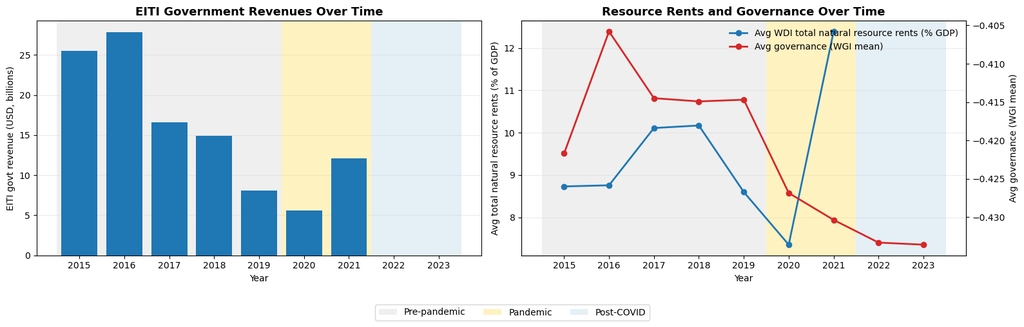

```python
# =====================================================
# VISUAL: Revenues & Governance Over Time
# - LEFT  : EITI Govt Revenues (USD, billions)
# - RIGHT : WDI Total Natural Resource Rents (% GDP) vs Governance (WGI mean)
# =====================================================

# -----------------------------
# 0) Safety checks + prep
# -----------------------------
needed = {
    "year",
    "eiti_revenue_government_usd",
    "total_natural_resource_rents_pct_gdp",
    "wgi_mean"
}
missing = needed - set(merged_df.columns)
if missing:
    raise ValueError(f"merged_df missing required columns: {sorted(missing)}")

df = merged_df.loc[
    merged_df["year"].between(WINDOW_START, WINDOW_END),
    [
        "year",
        "eiti_revenue_government_usd",
        "total_natural_resource_rents_pct_gdp",
        "wgi_mean"
    ]
].copy()

df["year"] = df["year"].astype(int)
df["eiti_revenue_government_usd"] = pd.to_numeric(
    df["eiti_revenue_government_usd"], errors="coerce"
)
df["total_natural_resource_rents_pct_gdp"] = pd.to_numeric(
    df["total_natural_resource_rents_pct_gdp"], errors="coerce"
)
df["wgi_mean"] = pd.to_numeric(df["wgi_mean"], errors="coerce")

# -----------------------------
# 1) Aggregations
# -----------------------------
# LEFT: EITI revenues in USD (convert to billions)
rev_usd = (
    df.groupby("year", as_index=False)
      .agg(eiti_revenue_usd=("eiti_revenue_government_usd", "sum"))
)
rev_usd["eiti_revenue_usd"] = rev_usd["eiti_revenue_usd"] / 1e9  # billions USD

# RIGHT: WDI rents + governance
yearly = (
    df.groupby("year", as_index=False)
      .agg(
          rents_pct_gdp=("total_natural_resource_rents_pct_gdp", "mean"),
          wgi_mean=("wgi_mean", "mean")
      )
)

# Ensure full year coverage
rev_usd = pd.DataFrame({"year": ALL_YEARS}).merge(rev_usd, on="year", how="left")
yearly  = pd.DataFrame({"year": ALL_YEARS}).merge(yearly,  on="year", how="left")

# -----------------------------
# 2) Figure + subplots
# -----------------------------
fig, axes = plt.subplots(
    nrows=1, ncols=2,
    figsize=(16, 5),
    sharex=True
)

# =====================================================
# LEFT: EITI Govt Revenues (USD, billions)
# =====================================================
axL = axes[0]

for _, label, start, end in PERIODS:
    axL.axvspan(
        start - 0.5, end + 0.5,
        color=PERIOD_COLORS[label],
        alpha=PERIOD_ALPHA,
        lw=0
    )

axL.bar(
    rev_usd["year"],
    rev_usd["eiti_revenue_usd"]
)

axL.set_title(
    "EITI Government Revenues Over Time",
    fontsize=13,
    fontweight="bold"
)
axL.set_xlabel("Year")
axL.set_ylabel("EITI govt revenue (USD, billions)")
axL.set_xticks(ALL_YEARS)
axL.grid(True, axis="y", alpha=0.25)
axL.set_axisbelow(True)

# =====================================================
# RIGHT: WDI Resource Rents vs Governance
# =====================================================
axR1 = axes[1]
axR2 = axR1.twinx()

for _, label, start, end in PERIODS:
    axR1.axvspan(
        start - 0.5, end + 0.5,
        color=PERIOD_COLORS[label],
        alpha=PERIOD_ALPHA,
        lw=0
    )

# WDI resource rents
axR1.plot(
    yearly["year"],
    yearly["rents_pct_gdp"],
    marker="o",
    linewidth=2,
    color="#1f77b4",
    label="Avg WDI total natural resource rents (% GDP)"
)
axR1.set_ylabel("Avg total natural resource rents (% of GDP)")

# Governance
axR2.plot(
    yearly["year"],
    yearly["wgi_mean"],
    marker="o",
    linewidth=2,
    color="#d62728",
    label="Avg governance (WGI mean)"
)
axR2.set_ylabel("Avg governance (WGI mean)")

axR1.set_title(
    "Resource Rents and Governance Over Time",
    fontsize=13,
    fontweight="bold"
)
axR1.set_xlabel("Year")
axR1.set_xticks(ALL_YEARS)
axR1.grid(True, axis="y", alpha=0.25)
axR1.set_axisbelow(True)

# Combined legend (right panel)
lines1, labels1 = axR1.get_legend_handles_labels()
lines2, labels2 = axR2.get_legend_handles_labels()
axR2.legend(
    lines1 + lines2,
    labels1 + labels2,
    frameon=False,
    loc="upper right"
)

# =====================================================
# Shared period legend
# =====================================================
period_handles = [
    Patch(
        facecolor=PERIOD_COLORS[label],
        edgecolor="none",
        alpha=PERIOD_ALPHA,
        label=label
    )
    for _, label, _, _ in PERIODS
]

fig.legend(
    handles=period_handles,
    loc="lower center",
    ncol=3,
    frameon=True,
    bbox_to_anchor=(0.5, -0.02)
)

plt.tight_layout(rect=[0, 0.08, 1, 1])
plt.show()
```

The left panel shows that government revenues from extractive industries are highly volatile, with a pronounced decline during the pandemic period and only a partial recovery thereafter. This highlights the exposure of resource-dependent countries to global shocks and demand shifts, particularly as oil and gas markets face increasing uncertainty.

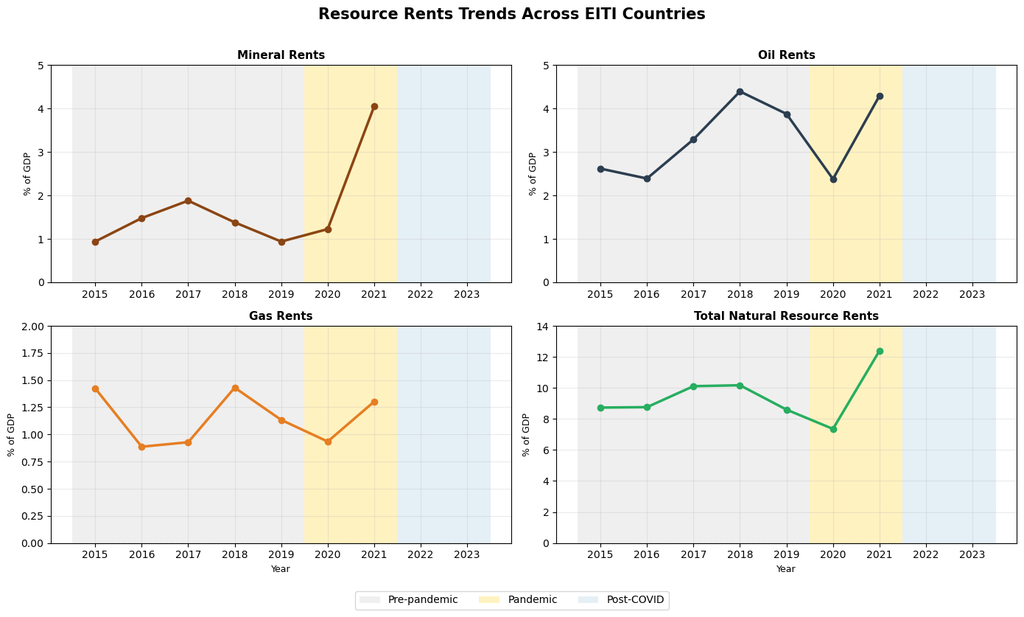

```python
# =====================================================
# Trends in resource rent across EITI countries
# =====================================================

rent_cols = [
    "mineral_rents_pct_gdp",
    "oil_rents_pct_gdp",
    "gas_rents_pct_gdp",
    "total_natural_resource_rents_pct_gdp"
]

# Compute average rent trends
rent_trend = merged_df.groupby("year")[rent_cols].mean().reset_index()
rent_trend = pd.DataFrame({"year": list(range(2015, 2024))}).merge(rent_trend, how="left")

fig2, axes2 = plt.subplots(2, 2, figsize=(14, 8), sharex=True)
axes2 = axes2.flatten()

rent_titles = ["Mineral Rents", "Oil Rents", "Gas Rents", "Total Natural Resource Rents"]
rent_colors = ["#8B4513", "#2C3E50", "#E67E22", "#27AE60"]

for ax, col, title_text, color in zip(axes2, rent_cols, rent_titles, rent_colors):

    # Period shading
    for _, label, start, end in PERIODS:
        ax.axvspan(
            start - 0.5, end + 0.5,
            alpha=PERIOD_ALPHA,
            color=PERIOD_COLORS[label],
            lw=0
        )

    # Plot series
    ax.plot(rent_trend["year"], rent_trend[col],
            marker="o", linewidth=2.5, color=color)

    # Formatting
    ax.axhline(0, linestyle="--", linewidth=1, alpha=0.3, color="gray")
    ax.set_title(title_text, fontweight="bold", fontsize=11)
    ax.set_ylabel("% of GDP", fontsize=9)
    ax.grid(True, alpha=0.25)
    ax.set_xticks(list(range(2015, 2024)))

# tick labels
for ax in axes2:
    ax.tick_params(axis="x", labelbottom=True)

# Fixed y-limits per panel
axes2[0].set_ylim(0, 5)    # Mineral
axes2[1].set_ylim(0, 5)    # Oil
axes2[2].set_ylim(0, 2)    # Gas
axes2[3].set_ylim(0, 14)   # Total

# X-axis labels only on bottom row
for ax in axes2[2:]:
    ax.set_xlabel("Year", fontsize=9)

# Legend
period_handles = [
    Patch(facecolor=PERIOD_COLORS[label],
          edgecolor="none",
          alpha=PERIOD_ALPHA,
          label=label)
    for _, label, _, _ in PERIODS
]

fig2.legend(
    handles=period_handles,
    loc="lower center",
    ncol=3,
    frameon=True,
    bbox_to_anchor=(0.5, -0.02)
)

# Title
fig2.suptitle(
    "Resource Rents Trends Across EITI Countries",
    y=1.01,
    fontsize=15,
    fontweight="bold"
)

plt.tight_layout(rect=[0, 0.03, 1, 1])
plt.show()
```

Furthermore, we examine trends in resource rents by commodity type. Total natural resource rents as a share of GDP rose sharply to nearly 12% in 2021 among EITI countries, as shown in the figure above. This increase is largely driven by a substantial rise in mineral rents, which increased from around 1% of GDP in 2015 to approximately 4% by 2021. Oil rents exhibit a more modest recovery over the same period, while gas rents remain relatively stable.

### III.2 Governance Trends Across EITI-Implementing Countries

We analyze trends in the six Worldwide Governance Indicators to assess whether specific dimensions of governance exhibit systematic improvement or deterioration over the study period.

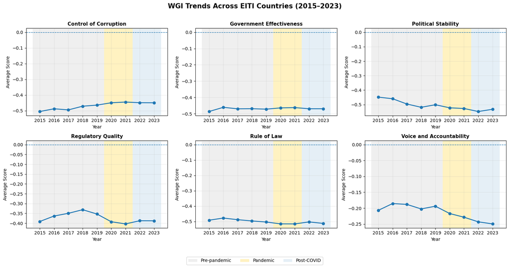

```python
# =====================================================
# VISUAL: WGI TRENDS (AVG ACROSS EITI COUNTRIES)
# - are the series trending up/down, and when (pre/pandemic/post)
# =====================================================

def add_period_labels(df, year_col="year"):
    out = df.copy()
    out[year_col] = out[year_col].astype(int)
    out["period"] = np.nan
    for key, _, start, end in PERIODS:
        out.loc[out[year_col].between(start, end), "period"] = key
    return out

needed = {"year", *WGI_COLS}
missing = needed - set(merged_df.columns)
if missing:
    raise ValueError(f"merged_df missing required columns: {sorted(missing)}")

dfv = merged_df.copy()
dfv["year"] = dfv["year"].astype(int)

trend = (
    dfv.loc[dfv["year"].between(2015, 2023), ["year"] + WGI_COLS]
       .groupby("year", as_index=False)
       .mean(numeric_only=True)
)

trend = pd.DataFrame({"year": ALL_YEARS}).merge(trend, on="year", how="left")

fig, axes = plt.subplots(2, 3, figsize=(16, 8), sharex=True)
axes = axes.flatten()

for ax, col in zip(axes, WGI_COLS):
    for _, label, start, end in PERIODS:
        ax.axvspan(start - 0.5, end + 0.5, alpha=PERIOD_ALPHA,
                   color=PERIOD_COLORS[label], lw=0)

    ax.plot(trend["year"], trend[col], marker="o", linewidth=2)
    ax.axhline(0, linestyle="--", linewidth=1)

    ax.set_title(
    TITLE_MAP.get(col, col),
    fontweight="bold",
    fontsize=11
)
    ax.set_xlabel("Year")
    ax.set_ylabel("Average Score")
    ax.grid(True, alpha=0.25)

    ax.set_xticks(ALL_YEARS)
    ax.tick_params(axis="x", labelbottom=True)

legend_handles = [
    Patch(facecolor=PERIOD_COLORS[label], edgecolor="none",
          alpha=PERIOD_ALPHA, label=label)
    for _, label, _, _ in PERIODS
]
fig.legend(handles=legend_handles, loc="lower center", ncol=3,
           frameon=True, bbox_to_anchor=(0.5, -0.02))

fig.suptitle(
    "WGI Trends Across EITI Countries (2015–2023)",
    y=1.01,
    fontsize=15,
    fontweight="bold"
)
plt.tight_layout(rect=[0, 0.06, 1, 1])
plt.show()
```

If the economic significance and volatility of extractive revenues were translating into stronger institutions, this should be visible in broad improvements in governance over time. The figure above examines this directly by tracing trends in the six WGI Indicators across EITI countries between 2015 and 2023. Across all dimensions, average scores remain persistently below the WGI zero benchmark—which represents the global mean by construction—and display no clear upward trajectory. Rather than improving, most indicators either stagnate or gradually deteriorate, suggesting that participation in extractive activity and exposure to large fiscal flows do not, on average, generate automatic governance gains.

### III.3 Heterogeneity in Governance Changes Across Countries

We next move beyond average trends to examine the extent of cross-country heterogeneity in governance changes between the pre-pandemic and post-pandemic periods.

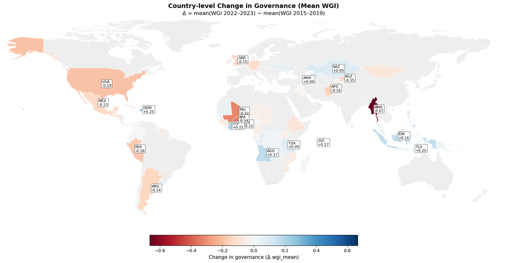

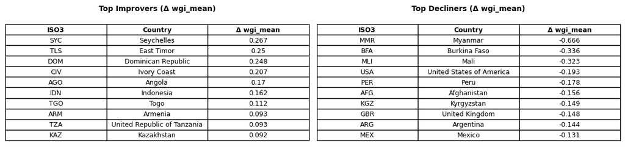

```python
# =====================================================
# VISUAL: Country-level governance change world map
#   Δ = mean(WGI POST) − mean(WGI PRE)
# - adds geography: where improvements/declines are concentrated
# =====================================================

# -----------------------------
# 0) Safety checks + prep
# -----------------------------
needed = {"iso3c", "year", "wgi_mean"}
missing = needed - set(merged_df.columns)
if missing:
    raise ValueError(f"merged_df missing required columns: {sorted(missing)}")

df = merged_df.loc[
    merged_df["year"].between(WINDOW_START, WINDOW_END),
    ["iso3c", "year", "wgi_mean"]
].copy()

df["iso3c"] = df["iso3c"].astype(str).str.upper().str.strip()
df["year"] = df["year"].astype(int)
df["wgi_mean"] = pd.to_numeric(df["wgi_mean"], errors="coerce")
df = df.dropna(subset=["iso3c", "year", "wgi_mean"])

# -----------------------------
# 1) Compute country-level PRE vs POST means + Δ
# -----------------------------
pre = (
    df.loc[df["year"].between(PRE_START, PRE_END)]
      .groupby("iso3c", as_index=False)["wgi_mean"]
      .mean()
      .rename(columns={"wgi_mean": "pre_mean"})
)

post = (
    df.loc[df["year"].between(POST_START, POST_END)]
      .groupby("iso3c", as_index=False)["wgi_mean"]
      .mean()
      .rename(columns={"wgi_mean": "post_mean"})
)

delta_df = (
    pre.merge(post, on="iso3c", how="inner")
       .assign(delta_post_minus_pre=lambda d: d["post_mean"] - d["pre_mean"])
       .loc[:, ["iso3c", "pre_mean", "post_mean", "delta_post_minus_pre"]]
       .copy()
)

# keep only valid deltas
delta_df["delta_post_minus_pre"] = pd.to_numeric(delta_df["delta_post_minus_pre"], errors="coerce")
delta_df = delta_df.dropna(subset=["delta_post_minus_pre"])

# -----------------------------
# 2) Load world boundaries (Natural Earth) + merge Δ
# -----------------------------
WORLD_URL = (
    "https://naturalearth.s3.amazonaws.com/50m_cultural/"
    "ne_50m_admin_0_countries.zip"
)

world = gpd.read_file(WORLD_URL)
world = world.loc[:, ["ISO_A3", "ADMIN", "geometry"]].rename(
    columns={"ISO_A3": "iso3c", "ADMIN": "country"}
)
world["iso3c"] = world["iso3c"].astype(str).str.upper().str.strip()

map_df = world.merge(
    delta_df.loc[:, ["iso3c", "delta_post_minus_pre"]],
    on="iso3c",
    how="left"
)

# for ranking/tables: only those that exist on the map + have delta
available = map_df.dropna(subset=["delta_post_minus_pre"]).copy()

# -----------------------------
# 3) Choose label countries (top/bottom K by Δ)
# -----------------------------
TOP_K = 10

top_improvers_iso3 = available.nlargest(TOP_K, "delta_post_minus_pre")["iso3c"].tolist()
top_decliners_iso3 = available.nsmallest(TOP_K, "delta_post_minus_pre")["iso3c"].tolist()
label_iso3 = set(top_improvers_iso3 + top_decliners_iso3)

# -----------------------------
# 4) Plot map
# -----------------------------
cmap = plt.cm.RdBu  # red = negative, blue = positive
vmax = float(np.nanmax(np.abs(map_df["delta_post_minus_pre"])))
norm = TwoSlopeNorm(vmin=-vmax, vcenter=0, vmax=vmax)

fig, ax = plt.subplots(figsize=(16, 8))

# base layer (all countries)
map_df.plot(ax=ax, color="#EEEEEE", edgecolor="white", linewidth=0.4)

# data layer (only those with delta)
map_df.dropna(subset=["delta_post_minus_pre"]).plot(
    ax=ax,
    column="delta_post_minus_pre",
    cmap=cmap,
    norm=norm,
    edgecolor="white",
    linewidth=0.4
)

ax.set_title(
    "Country-level Change in Governance (Mean WGI)",
    fontsize=14,
    fontweight="bold",
    pad=22
)

ax.text(
    0.5, 1.01,
    f"Δ = mean(WGI {POST_START}–{POST_END}) − mean(WGI {PRE_START}–{PRE_END})",
    transform=ax.transAxes,
    ha="center",
    va="bottom",
    fontsize=12
)

ax.set_axis_off()

# consistent view window
ax.set_xlim(-170, 190)
ax.set_ylim(-60, 85)

# -----------------------------
# 5) Label top improvers/decliners (ISO3 + Δ)
# -----------------------------
label_df = map_df.loc[map_df["iso3c"].isin(label_iso3)].dropna(subset=["delta_post_minus_pre"]).copy()

# representative_point avoids multipolygon centroid issues
label_df["pt"] = label_df.geometry.representative_point()
label_df["x"] = label_df["pt"].x
label_df["y"] = label_df["pt"].y

for _, r in label_df.iterrows():
    ax.text(
        r["x"] + 0.8,
        r["y"] + 0.6,
        f"{r['iso3c']}\n{r['delta_post_minus_pre']:+.2f}",
        fontsize=8,
        ha="left",
        va="center",
        bbox=dict(boxstyle="round,pad=0.2", fc="white", ec="black", lw=0.5, alpha=0.9),
        zorder=5
    )

# -----------------------------
# 6) Colorbar (bottom)
# -----------------------------
sm = ScalarMappable(norm=norm, cmap=cmap)
sm._A = []

cbar = fig.colorbar(
    sm, ax=ax,
    orientation="horizontal",
    fraction=0.045,
    pad=0.06
)
cbar.set_label("Change in governance (Δ wgi_mean)", fontsize=11)
cbar.ax.tick_params(labelsize=10)

plt.tight_layout()
plt.show()

# -----------------------------
# 7) Side-by-side tables: Top improvers vs decliners
# -----------------------------
rank_df = (
    available.loc[:, ["iso3c", "country", "delta_post_minus_pre"]]
             .drop_duplicates(subset=["iso3c"])
             .rename(columns={"delta_post_minus_pre": "delta"})
             .copy()
)

rank_df["delta"] = pd.to_numeric(rank_df["delta"], errors="coerce")

top_improvers_tbl = rank_df.nlargest(TOP_K, "delta").assign(delta=lambda d: d["delta"].round(3))
top_decliners_tbl = rank_df.nsmallest(TOP_K, "delta").assign(delta=lambda d: d["delta"].round(3))

fig, axes = plt.subplots(1, 2, figsize=(12, 3))
for ax in axes:
    ax.axis("off")

# left table
axes[0].set_title("Top Improvers (Δ wgi_mean)", fontsize=10, fontweight="bold", pad=10)
t1 = axes[0].table(
    cellText=top_improvers_tbl[["iso3c", "country", "delta"]].values,
    colLabels=["ISO3", "Country", "Δ wgi_mean"],
    loc="center",
    cellLoc="center",
    bbox=[0, 0.05, 1, 0.9]
)
t1.auto_set_font_size(False)
t1.set_fontsize(9)
t1.scale(1, 1.4)
for (row, col), cell in t1.get_celld().items():
    if row == 0:
        cell.set_text_props(weight="bold")

# right table
axes[1].set_title("Top Decliners (Δ wgi_mean)", fontsize=10, fontweight="bold", pad=10)
t2 = axes[1].table(
    cellText=top_decliners_tbl[["iso3c", "country", "delta"]].values,
    colLabels=["ISO3", "Country", "Δ wgi_mean"],
    loc="center",
    cellLoc="center",
    bbox=[0, 0.05, 1, 0.9]
)
t2.auto_set_font_size(False)
t2.set_fontsize(9)
t2.scale(1, 1.4)
for (row, col), cell in t2.get_celld().items():
    if row == 0:
        cell.set_text_props(weight="bold")

plt.tight_layout()
plt.show()
```

Looking beyond averages to country-level changes reveals a far more uneven geography of governance outcomes. As shown in the figure above, most countries experience relatively small shifts in mean governance scores, but these modest movements coexist with a small number of pronounced gains and losses. In the Western Hemisphere, changes are generally limited in magnitude and skew slightly negative, pointing to gradual erosion rather than abrupt institutional breakdown. By contrast, countries in the Eastern Hemisphere display much wider dispersion, with several registering moderate improvements alongside a handful of sharp declines. In particular, large deteriorations in countries such as Myanmar—and to a lesser extent in parts of Africa and Central Asia—account for a disproportionate share of the overall downward movement observed in the distribution. This pattern helps explain why aggregate governance trends appear stagnant: deterioration is not widespread, but instead driven by extreme movements in a small number of countries. As a result, understanding governance dynamics in resource-rich countries requires attention not only to average trends, but also to the concentration and severity of country-specific institutional changes.

### III.4 Average Governance Levels Across EITI-Implementing Countries

We summarize long-run differences in institutional quality by mapping average governance levels across countries over the full 2015–2023 period.

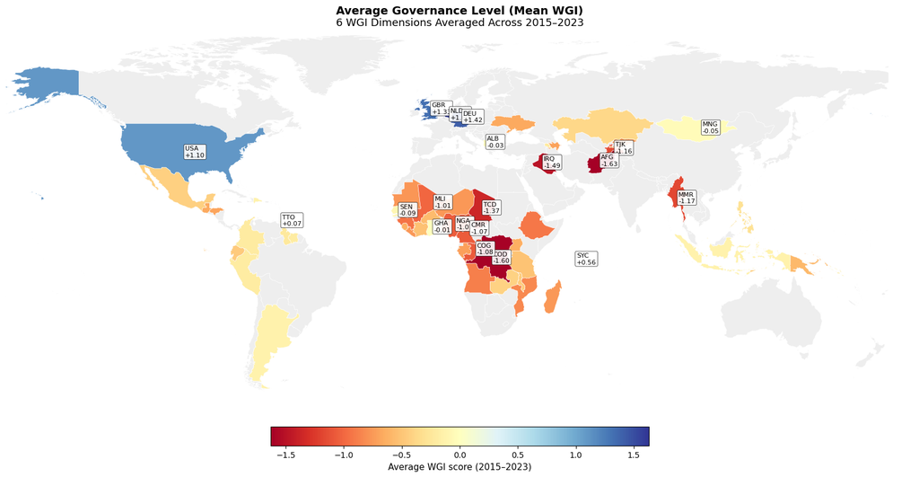

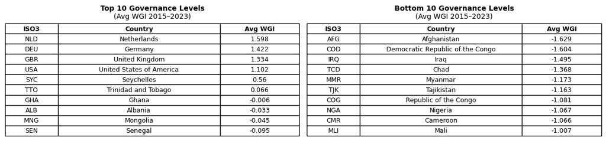

```python
# =====================================================
# VISUAL: Average Governance Level world map (overall level)
#   Level = country mean of wgi_mean over 2015-2023
# - shows starting/overall levels (important because “improving” ≠ “good”; some improve from very low baselines
# =====================================================

# -----------------------------
# 0) Safety checks + compute country-level levels
# -----------------------------
needed = {"iso3c", "year", "wgi_mean"}
missing = needed - set(merged_df.columns)
if missing:
    raise ValueError(f"merged_df missing required columns: {sorted(missing)}. "
                     f"Make sure you computed wgi_mean earlier.")

df = merged_df.loc[
    merged_df["year"].between(WINDOW_START, WINDOW_END),
    ["iso3c", "year", "wgi_mean"]
].copy()

df["iso3c"] = df["iso3c"].astype(str).str.upper().str.strip()
df["year"] = df["year"].astype(int)

level_df = (
    df.groupby("iso3c", as_index=False)["wgi_mean"]
      .mean()
      .rename(columns={"wgi_mean": "avg_wgi_level"})
)

# -----------------------------
# 1) Load world boundaries
# -----------------------------
WORLD_URL = (
    "https://naturalearth.s3.amazonaws.com/50m_cultural/"
    "ne_50m_admin_0_countries.zip"
)

world = gpd.read_file(WORLD_URL)
world = world.loc[:, ["ISO_A3", "ADMIN", "geometry"]].rename(
    columns={"ISO_A3": "iso3c", "ADMIN": "country"}
)
world["iso3c"] = world["iso3c"].astype(str).str.upper().str.strip()

# -----------------------------
# 2) Merge LEVEL onto map
# -----------------------------
map_df = world.merge(level_df, on="iso3c", how="left")

# -----------------------------
# 3) Select countries to label (Top/Bottom K by level)
# -----------------------------
TOP_K = 10

available = map_df.dropna(subset=["avg_wgi_level"]).copy()

top_iso3 = available.nlargest(TOP_K, "avg_wgi_level")["iso3c"].tolist()
bot_iso3 = available.nsmallest(TOP_K, "avg_wgi_level")["iso3c"].tolist()
label_iso3 = set(top_iso3 + bot_iso3)

# -----------------------------
# 4) Plot map
# -----------------------------
cmap = plt.cm.RdYlBu  # low=red, high=blue
vmax = float(np.nanmax(np.abs(map_df["avg_wgi_level"])))
norm = TwoSlopeNorm(vmin=-vmax, vcenter=0.0, vmax=vmax)

fig, ax = plt.subplots(figsize=(16, 8))

# base layer
map_df.plot(ax=ax, color="#EEEEEE", edgecolor="white", linewidth=0.4)

# data layer
map_df.dropna(subset=["avg_wgi_level"]).plot(
    ax=ax,
    column="avg_wgi_level",
    cmap=cmap,
    norm=norm,
    edgecolor="white",
    linewidth=0.4
)

ax.set_title(
    "Average Governance Level (Mean WGI)",
    fontsize=14,
    fontweight="bold",
    pad=22
)

ax.text(
    0.5, 1.01,
    f"6 WGI Dimensions Averaged Across {WINDOW_START}–{WINDOW_END}",
    transform=ax.transAxes,
    ha="center",
    va="bottom",
    fontsize=13
)
ax.set_axis_off()
ax.set_xlim(-170, 190)
ax.set_ylim(-60, 85)

# -----------------------------
# 5) Labels (Top/Bottom K)
# -----------------------------
label_df = map_df.loc[map_df["iso3c"].isin(label_iso3)].dropna(subset=["avg_wgi_level"]).copy()

label_df["pt"] = label_df.geometry.representative_point()
label_df["x"] = label_df["pt"].x
label_df["y"] = label_df["pt"].y

for _, r in label_df.iterrows():
    ax.text(
        r["x"] + 0.8,
        r["y"] + 0.6,
        f"{r['iso3c']}\n{r['avg_wgi_level']:+.2f}",
        fontsize=8,
        ha="left",
        va="center",
        bbox=dict(boxstyle="round,pad=0.2", fc="white", ec="black", lw=0.5, alpha=0.9),
        zorder=5
    )

# -----------------------------
# 6) Colorbar (bottom)
# -----------------------------
sm = ScalarMappable(norm=norm, cmap=cmap)
sm._A = []

cbar = fig.colorbar(
    sm, ax=ax,
    orientation="horizontal",
    fraction=0.045,
    pad=0.06
)
cbar.set_label(f"Average WGI score ({WINDOW_START}–{WINDOW_END})", fontsize=11)
cbar.ax.tick_params(labelsize=10)

plt.tight_layout()
plt.show()

# -----------------------------
# 7) Side-by-side tables (Top vs Bottom K)
# -----------------------------
rank_df = (
    available.loc[:, ["iso3c", "country", "avg_wgi_level"]]
             .drop_duplicates(subset=["iso3c"])
             .rename(columns={"avg_wgi_level": "avg_wgi"})
             .copy()
)

top_tbl = rank_df.nlargest(TOP_K, "avg_wgi").assign(avg_wgi=lambda d: d["avg_wgi"].round(3))
bot_tbl = rank_df.nsmallest(TOP_K, "avg_wgi").assign(avg_wgi=lambda d: d["avg_wgi"].round(3))

fig, axes = plt.subplots(1, 2, figsize=(12, 3))
for a in axes:
    a.axis("off")

axes[0].set_title(f"Top {TOP_K} Governance Levels", fontsize=10, fontweight="bold", pad=10)
axes[0].text(
    0.5, 0.98,
    f"(Avg WGI {WINDOW_START}–{WINDOW_END})",
    transform=axes[0].transAxes,
    ha="center", va="bottom",
    fontsize=10, fontweight="normal"
)
t1 = axes[0].table(
    cellText=top_tbl[["iso3c", "country", "avg_wgi"]].values,
    colLabels=["ISO3", "Country", "Avg WGI"],
    loc="center",
    cellLoc="center",
    colWidths=[0.18, 0.55, 0.27],
    bbox=[0, 0.05, 1, 0.9]
)
t1.auto_set_font_size(False)
t1.set_fontsize(9)
t1.scale(1, 1.4)
for (row, col), cell in t1.get_celld().items():
    if row == 0:
        cell.set_text_props(weight="bold")

axes[1].set_title(f"Bottom {TOP_K} Governance Levels", fontsize=10, fontweight="bold", pad=10)
axes[1].text(
    0.5, 0.98,
    f"(Avg WGI {WINDOW_START}–{WINDOW_END})",
    transform=axes[1].transAxes,
    ha="center", va="bottom",
    fontsize=10, fontweight="normal"
)
t2 = axes[1].table(
    cellText=bot_tbl[["iso3c", "country", "avg_wgi"]].values,
    colLabels=["ISO3", "Country", "Avg WGI"],
    loc="center",
    cellLoc="center",
    colWidths=[0.18, 0.55, 0.27],
    bbox=[0, 0.05, 1, 0.9]
)
t2.auto_set_font_size(False)
t2.set_fontsize(9)
t2.scale(1, 1.4)
for (row, col), cell in t2.get_celld().items():
    if row == 0:
        cell.set_text_props(weight="bold")

plt.tight_layout()
plt.show()
```

Stepping back from short-term changes and focusing on average governance levels over the full 2015–2023 period reveals a strikingly stable spatial pattern. As shown in the figure above, EITI countries in Western Europe and North America consistently occupy the top of the governance distribution, while much of Sub-Saharan Africa and parts of South and Central Asia remain clustered at the bottom. These gaps are large and persistent, reflecting differences in long-standing institutional capacity rather than temporary shocks or cyclical movements. A small number of countries—such as Seychelles and Trinidad and Tobago—emerge as notable regional exceptions, but they do not alter the broader picture of stratification. Taken together with the trend and change analyses, this evidence suggests that recent volatility in extractive revenues and global disruptions, including the COVID-19 pandemic and the energy transition, have done little to reshape underlying governance hierarchies. Instead, governance outcomes among resource-rich countries appear to be anchored in deep-rooted institutional conditions, with geography and historical state capacity playing a more decisive role than short-run revenue dynamics.

### III.5 Correlation Structure of Governance Dimensions

To understand whether governance dimensions capture distinct institutional features or a common underlying factor, we examine the correlation structure among the six Worldwide Governance Indicators.

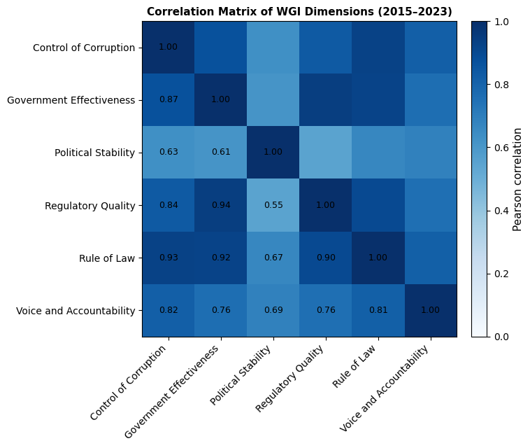

```python
# =====================================================
# VISUAL: Correlation matrix of WGI dimensions
#   - Pearson correlations
#   - Country–year observations (pooled, 2015–2023)
#   - Lower triangle only + annotated coefficients
# - shows the dimensions move together (supports using wgi_mean as a summary outcome)
# =====================================================

# -----------------------------
# 0) Safety check
# -----------------------------
needed = {"year", *WGI_COLS}
missing = needed - set(merged_df.columns)
if missing:
    raise ValueError(f"merged_df missing required columns: {sorted(missing)}")

# -----------------------------
# 1) Prepare data (analysis window)
# -----------------------------
corr_df = (
    merged_df.loc[merged_df["year"].between(WINDOW_START, WINDOW_END), WGI_COLS]
             .dropna()
)

# -----------------------------
# 2) Correlation matrix
# -----------------------------
corr_matrix = corr_df.corr(method="pearson")

# -----------------------------
# 3) Mask upper triangle
# -----------------------------
mask = np.triu(np.ones_like(corr_matrix, dtype=bool), k=1)

# -----------------------------
# 4) Plot
# -----------------------------
fig, ax = plt.subplots(figsize=(7.5, 6.5))

im = ax.imshow(
    corr_matrix,
    cmap="Blues",
    vmin=0, vmax=1  # 0 = white, 1 = darkest
)

# ticks & labels
pretty_labels = [TITLE_MAP.get(c, c.replace("_", " ").title()) for c in WGI_COLS]
ax.set_xticks(range(len(WGI_COLS)))
ax.set_yticks(range(len(WGI_COLS)))
ax.set_xticklabels(pretty_labels, rotation=45, ha="right")
ax.set_yticklabels(pretty_labels)

# annotate lower triangle only
for i in range(len(WGI_COLS)):
    for j in range(len(WGI_COLS)):
        if not mask[i, j]:
            ax.text(
                j, i,
                f"{corr_matrix.iloc[i, j]:.2f}",
                ha="center", va="center",
                fontsize=9
            )

# colorbar
cbar = fig.colorbar(im, ax=ax, fraction=0.046, pad=0.04)
cbar.set_label("Pearson correlation", fontsize=11)
cbar.ax.tick_params(labelsize=10)

ax.set_title("Correlation Matrix of WGI Dimensions (2015–2023)", fontsize=11,  fontweight="bold")
plt.tight_layout()
plt.show()
```

Taken together, the six dimensions of the Worldwide Governance Indicators exhibit strong positive correlations over the 2015–2023 period, indicating that governance outcomes tend to move together rather than independently. As shown in the above figure, countries that perform well in areas such as control of corruption or regulatory quality also tend to score highly on rule of law, government effectiveness, and voice and accountability. This pattern points to the presence of a dominant underlying governance factor, where cross-country differences reflect overall institutional quality rather than distinct or specialized governance profiles. Political stability stands out as somewhat less tightly correlated with the other indicators, suggesting that it captures an additional source of variation related to conflict and security conditions. Nonetheless, the overall structure of correlations implies that differences observed across countries—and across the maps and trend analyses presented earlier—are driven primarily by broad governance capacity. Consequently, when countries are grouped or compared, separation should be interpreted mainly as reflecting different governance regimes (high, medium, or low quality), rather than fundamentally different institutional configurations.

### III.6 Governance Regimes: Clustering Countries by Institutional Quality

Building on the strong co-movement across governance dimensions, we use clustering and principal component analysis to identify whether countries group into distinct governance regimes based on overall institutional quality.

```
Clustering feature matrix X: n_countries=59, n_features=12
```

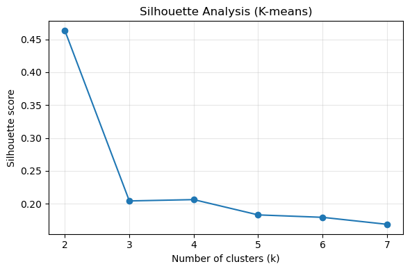

```
Silhouette scores:
  k=2: 0.463
  k=3: 0.204
  k=4: 0.206
  k=5: 0.183
  k=6: 0.179
  k=7: 0.169

--- Cluster summary means (k=2) ---
```

| cluster | control_of_corruption_baseline_2019_2021 | government_effectiveness_baseline_2019_2021 | political_stability_baseline_2019_2021 | regulatory_quality_baseline_2019_2021 | rule_of_law_baseline_2019_2021 | voice_and_accountability_baseline_2019_2021 | delta_control_of_corruption | delta_government_effectiveness | delta_political_stability | delta_regulatory_quality | delta_rule_of_law | delta_voice_and_accountability |
| --- | --- | --- | --- | --- | --- | --- | --- | --- | --- | --- | --- | --- |
| 0 | -0.65 | -0.65 | -0.62 | -0.57 | -0.71 | -0.36 | 0.05 | 0.02 | -0.05 | -0.02 | -0.00 | -0.05 |
| 1 | 1.72 | 1.53 | 0.63 | 1.60 | 1.61 | 1.34 | -0.10 | -0.22 | -0.13 | -0.17 | -0.16 | -0.01 |

```
Cluster sizes:
cluster_label
Non-Strong Governance    54
Strong Governance         5
Name: count, dtype: int64

--- Cluster summary means (k=3) ---
```

| cluster | control_of_corruption_baseline_2019_2021 | government_effectiveness_baseline_2019_2021 | political_stability_baseline_2019_2021 | regulatory_quality_baseline_2019_2021 | rule_of_law_baseline_2019_2021 | voice_and_accountability_baseline_2019_2021 | delta_control_of_corruption | delta_government_effectiveness | delta_political_stability | delta_regulatory_quality | delta_rule_of_law | delta_voice_and_accountability |
| --- | --- | --- | --- | --- | --- | --- | --- | --- | --- | --- | --- | --- |
| 0 | 1.72 | 1.53 | 0.63 | 1.60 | 1.61 | 1.34 | -0.10 | -0.22 | -0.13 | -0.17 | -0.16 | -0.01 |
| 1 | -0.99 | -0.92 | -1.09 | -0.77 | -0.99 | -0.78 | -0.07 | -0.04 | -0.13 | -0.08 | -0.06 | -0.15 |
| 2 | -0.35 | -0.40 | -0.19 | -0.38 | -0.45 | 0.04 | 0.16 | 0.08 | 0.03 | 0.04 | 0.05 | 0.03 |

```
Cluster sizes:
cluster_label
Moderate Governance    28
Weak Governance        26
Strong Governance       5
Name: count, dtype: int64

PCA explained variance ratio: [0.42  0.245]

PC1 loadings (sorted by absolute magnitude):
```

|  | PC1_loading |
| --- | --- |
| rule_of_law_baseline_2019_2021 | 0.430 |
| government_effectiveness_baseline_2019_2021 | 0.422 |
| control_of_corruption_baseline_2019_2021 | 0.420 |
| regulatory_quality_baseline_2019_2021 | 0.409 |
| voice_and_accountability_baseline_2019_2021 | 0.394 |
| political_stability_baseline_2019_2021 | 0.336 |
| delta_voice_and_accountability | 0.120 |
| delta_regulatory_quality | -0.064 |
| delta_government_effectiveness | -0.062 |
| delta_rule_of_law | -0.056 |
| delta_political_stability | 0.004 |
| delta_control_of_corruption | -0.003 |

```
Top 6 contributors to PC1:
```

|  | PC1_loading |
| --- | --- |
| rule_of_law_baseline_2019_2021 | 0.430 |
| government_effectiveness_baseline_2019_2021 | 0.422 |
| control_of_corruption_baseline_2019_2021 | 0.420 |
| regulatory_quality_baseline_2019_2021 | 0.409 |
| voice_and_accountability_baseline_2019_2021 | 0.394 |
| political_stability_baseline_2019_2021 | 0.336 |

```
Bottom 6 contributors to PC1:
```

|  | PC1_loading |
| --- | --- |
| delta_voice_and_accountability | 0.120 |
| delta_regulatory_quality | -0.064 |
| delta_government_effectiveness | -0.062 |
| delta_rule_of_law | -0.056 |
| delta_political_stability | 0.004 |
| delta_control_of_corruption | -0.003 |

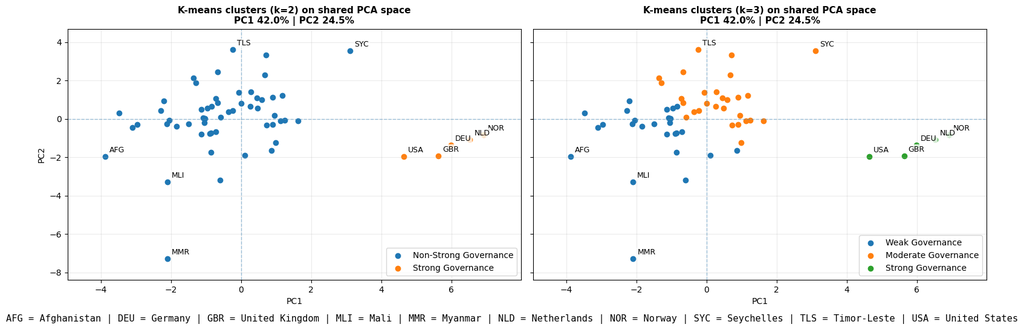

```
Membership (k=2):
```

|  | cluster_label | n | countries |
| --- | --- | --- | --- |
| 0 | Non-Strong Governance | 54 | AFG, AGO, ALB, ARG, ARM, AZE, BFA, CIV, CMR, COD, COG, COL, DOM, ECU, ETH, GAB, GHA, GIN, GTM, GUY, HND, IDN, IRQ, KAZ, KGZ, LBR, MDG, MEX, MLI, MMR, MNG, MOZ, MRT, MWI, NER, NGA, PER, PHL, PNG, SEN, … |
| 1 | Strong Governance | 5 | DEU, GBR, NLD, NOR, USA |

```
Membership (k=3):
```

|  | cluster_label | n | countries |
| --- | --- | --- | --- |
| 0 | Moderate Governance | 28 | AGO, ALB, ARG, ARM, CIV, COL, DOM, ECU, GHA, GUY, IDN, KAZ, MNG, MWI, PHL, PNG, SEN, SLB, SLE, STP, SUR, SYC, TGO, TLS, TTO, TZA, UKR, ZMB |
| 1 | Weak Governance | 26 | AFG, AZE, BFA, CMR, COD, COG, ETH, GAB, GIN, GTM, HND, IRQ, KGZ, LBR, MDG, MEX, MLI, MMR, MOZ, MRT, NER, NGA, PER, TCD, TJK, UGA |
| 2 | Strong Governance | 5 | DEU, GBR, NLD, NOR, USA |

```python
# =====================================================
# VISUAL: Governance Clustering (k=2 vs k=3)
#   - Features: baseline (2019–2021 mean of 6 WGI dims) + change (POST − PRE by dim)
#   - Shows:
#       (1) Silhouette analysis (k=2..7)
#       (2) Cluster summaries (means)
#       (3) PCA scatter: k=2 and k=3 side by side (same PCA space)
#       (4) Compact membership tables (ISO3s)
# =====================================================

# -----------------------------------------------------
# 0) Safety checks + minimal prep
# -----------------------------------------------------
needed = {"iso3c", "year", *WGI_COLS}
missing = needed - set(merged_df.columns)
if missing:
    raise ValueError(f"merged_df missing required columns: {sorted(missing)}")

df = merged_df.loc[
    merged_df["year"].between(WINDOW_START, WINDOW_END),
    ["iso3c", "year"] + WGI_COLS
].copy()

df["iso3c"] = df["iso3c"].astype(str).str.upper().str.strip()
df["year"] = pd.to_numeric(df["year"], errors="coerce")

for c in WGI_COLS:
    df[c] = pd.to_numeric(df[c], errors="coerce")

df = df.dropna(subset=["iso3c", "year"])

# -----------------------------------------------------
# 1) Construct clustering features: baseline + delta (per dimension)
# -----------------------------------------------------
BASE_START, BASE_END = 2019, 2021

baseline = (
    df.loc[df["year"].between(BASE_START, BASE_END)]
      .groupby("iso3c")[WGI_COLS]
      .mean()
      .dropna()
      .rename(columns=lambda c: f"{c}_baseline_{BASE_START}_{BASE_END}")
)

pre_means = (
    df.loc[df["year"].between(PRE_START, PRE_END)]
      .groupby("iso3c")[WGI_COLS]
      .mean()
)

post_means = (
    df.loc[df["year"].between(POST_START, POST_END)]
      .groupby("iso3c")[WGI_COLS]
      .mean()
)

delta = (post_means - pre_means).rename(columns=lambda c: f"delta_{c}")

X = baseline.join(delta, how="inner").dropna()

print(f"Clustering feature matrix X: n_countries={X.shape[0]}, n_features={X.shape[1]}")
if X.shape[0] < 5:
    raise ValueError(f"Too few countries with complete clustering features (n={X.shape[0]}).")

baseline_cols = [c for c in X.columns if "baseline" in c]
if len(baseline_cols) == 0:
    raise ValueError("No baseline columns found in X (expected columns containing 'baseline').")

# -----------------------------------------------------
# 2) Standardize features
# -----------------------------------------------------
scaler = StandardScaler()
X_scaled = scaler.fit_transform(X)

# -----------------------------------------------------
# 3) Silhouette analysis (k = 2..7)
# -----------------------------------------------------
sil_scores = {}
for k in range(2, 8):
    km = KMeans(n_clusters=k, random_state=42, n_init=20)
    labels = km.fit_predict(X_scaled)
    sil_scores[k] = float(silhouette_score(X_scaled, labels))

fig, ax = plt.subplots(figsize=(6, 4))
ax.plot(list(sil_scores.keys()), list(sil_scores.values()), marker="o")
ax.set_xlabel("Number of clusters (k)")
ax.set_ylabel("Silhouette score")
ax.set_title("Silhouette Analysis (K-means)")
ax.grid(alpha=0.3)
plt.tight_layout()
plt.show()

print("Silhouette scores:")
for k in sorted(sil_scores):
    print(f"  k={k}: {sil_scores[k]:.3f}")

# -----------------------------------------------------
# 4) Fit K-means for k=2 and k=3 and label clusters by baseline level
# -----------------------------------------------------
def make_cluster_labels(cluster_df, baseline_cols, k):
    # order clusters from low -> high baseline governance
    cluster_means = cluster_df.groupby("cluster")[baseline_cols].mean()
    order = cluster_means.mean(axis=1).sort_values().index.tolist()

    if k == 2:
        return {order[0]: "Non-Strong Governance", order[1]: "Strong Governance"}
    if k == 3:
        return {order[0]: "Weak Governance", order[1]: "Moderate Governance", order[2]: "Strong Governance"}
    return {cl: f"Cluster {cl}" for cl in order}

results = {}
for k in [2, 3]:
    km = KMeans(n_clusters=k, random_state=42, n_init=20)
    cl = km.fit_predict(X_scaled)

    cluster_df = X.copy()
    cluster_df["cluster"] = cl
    label_map = make_cluster_labels(cluster_df, baseline_cols, k)
    cluster_df["cluster_label"] = cluster_df["cluster"].map(label_map)

    results[k] = cluster_df

# -----------------------------------------------------
# 5) Cluster summaries (means)
# -----------------------------------------------------
for k in [2, 3]:
    print(f"\n--- Cluster summary means (k={k}) ---")
    display(
        results[k]
        .groupby("cluster")[X.columns]
        .mean()
        .round(2)
    )
    print("Cluster sizes:")
    print(results[k]["cluster_label"].value_counts())

# -----------------------------------------------------
# 6) PCA computed. plot for k=2 and k=3 + ISO3 labels on extremes
# -----------------------------------------------------
pca = PCA(n_components=2)
pcs = pca.fit_transform(X_scaled)

print("\nPCA explained variance ratio:", np.round(pca.explained_variance_ratio_, 3))

# -----------------------------
# PC loadings (what each PC represents)
# -----------------------------
loadings = pd.DataFrame(
    pca.components_.T,
    index=X.columns,
    columns=["PC1_loading", "PC2_loading"]
)

pc1_tbl = (
    loadings[["PC1_loading"]]
    .assign(abs_PC1=lambda d: d["PC1_loading"].abs())
    .sort_values("abs_PC1", ascending=False)
    .drop(columns="abs_PC1")
)

print("\nPC1 loadings (sorted by absolute magnitude):")
display(pc1_tbl.round(3))

print("\nTop 6 contributors to PC1:")
display(pc1_tbl.head(6).round(3))

print("\nBottom 6 contributors to PC1:")
display(pc1_tbl.tail(6).round(3))

def iso3_to_country(iso3):
    try:
        c = pycountry.countries.get(alpha_3=iso3)
        return c.name if c else iso3
    except Exception:
        return iso3

# -----------------------------
# PCA scores (shared across k=2 and k=3)
# -----------------------------
pca_base = pd.DataFrame(pcs, columns=["PC1", "PC2"], index=X.index)

# Choose extreme points once (same labels on both panels)
pca_base["dist"] = np.sqrt(pca_base["PC1"]**2 + pca_base["PC2"]**2)

LABEL_N = 10
label_iso3 = pca_base.nlargest(LABEL_N, "dist").index.tolist()

# Build ISO3 -> Country legend text (for labeled points only)
iso_country_pairs = [(iso, iso3_to_country(iso)) for iso in label_iso3]
iso_country_pairs = sorted(iso_country_pairs, key=lambda t: t[0])

legend_text = " | ".join([f"{iso} = {cty}" for iso, cty in iso_country_pairs])

# -----------------------------
# Axis padding
# -----------------------------
xmin, xmax = float(pca_base["PC1"].min()), float(pca_base["PC1"].max())
ymin, ymax = float(pca_base["PC2"].min()), float(pca_base["PC2"].max())

xpad = 0.10 * (xmax - xmin) if xmax > xmin else 1.0
ypad = 0.10 * (ymax - ymin) if ymax > ymin else 1.0

# -----------------------------
# Side-by-side PCA plots with labels
# -----------------------------
fig, axes = plt.subplots(ncols=2, figsize=(16, 6.5), sharex=True, sharey=True)

for ax, k in zip(axes, [2, 3]):
    cluster_df = results[k]
    plot_df = pca_base.copy()
    plot_df["cluster_label"] = cluster_df["cluster_label"].values

    # scatter by cluster label
    for lab in plot_df["cluster_label"].unique():
        sub = plot_df[plot_df["cluster_label"] == lab]
        ax.scatter(sub["PC1"], sub["PC2"], label=lab)

    # label the same extreme points in both panels
    for iso3 in label_iso3:
        r = plot_df.loc[iso3]
        ax.annotate(
            iso3,
            (r["PC1"], r["PC2"]),
            textcoords="offset points",
            xytext=(5, 5),
            fontsize=9,
            bbox=dict(boxstyle="round,pad=0.15", fc="white", ec="none", alpha=0.8)
        )

    ax.set_title(
        f"K-means clusters (k={k}) on shared PCA space\n"
        f"PC1 {pca.explained_variance_ratio_[0]*100:.1f}% | PC2 {pca.explained_variance_ratio_[1]*100:.1f}%",
        fontsize=11,
        fontweight="bold"
    )
    ax.axhline(0, linestyle="--", linewidth=1, alpha=0.4)
    ax.axvline(0, linestyle="--", linewidth=1, alpha=0.4)
    ax.grid(alpha=0.25)

    # legends: force bottom-right for both
    ax.legend(frameon=True, loc="lower right")

# set labels
axes[0].set_xlabel("PC1")
axes[0].set_ylabel("PC2")
axes[1].set_xlabel("PC1")

# widen limits so points don't clip
axes[0].set_xlim(xmin - xpad, xmax + xpad)
axes[0].set_ylim(ymin - ypad, ymax + ypad)

# leave space at the bottom for ISO3=Country legend text
plt.tight_layout()
plt.subplots_adjust(bottom=0.28)

# add ISO3=Country legend below both plots (single shared block)
fig.text(
    0.5, 0.18,
    legend_text,
    ha="center",
    va="center",
    fontsize=11,
    family="monospace"
)

plt.show()

# -----------------------------------------------------
# 7) Compact membership tables
# -----------------------------------------------------
def compact_membership(cluster_df):
    out = (
        cluster_df.reset_index(names="iso3c")
                  .groupby("cluster_label", as_index=False)
                  .agg(
                      n=("iso3c", "count"),
                      countries=("iso3c", lambda s: ", ".join(sorted(s)))
                  )
                  .sort_values("n", ascending=False)
                  .reset_index(drop=True)
    )
    return out

print("\nMembership (k=2):")
display(
    compact_membership(results[2])
    .style
    .set_properties(
        subset=["countries"],
        **{
            "white-space": "normal",
            "max-width": "900px",
            "font-size": "10pt"
        }
    )
)

print("\nMembership (k=3):")
display(
    compact_membership(results[3])
    .style
    .set_properties(
        subset=["countries"],
        **{
            "white-space": "normal",
            "max-width": "900px",
            "font-size": "10pt"
        }
    )
)
```

The clustering results reveal a simple but powerful structure in the data. The silhouette analysis indicates that the strongest separation occurs at k = 2, suggesting a clear divide between a small group of countries with exceptionally high governance levels and the rest of the countries. Introducing additional clusters leads to a sharp decline in silhouette scores, implying that further splits capture weaker, more descriptive distinctions rather than fundamentally different governance regimes.

The PCA results help clarify the nature of this separation. The first principal component explains 42 percent of total variation and is overwhelmingly driven by baseline governance measures—rule of law, government effectiveness, control of corruption, and regulatory quality—while changes over time contribute very little. In the shared PCA space, high-governance countries lie far to the right along this first axis, reinforcing the interpretation that the dominant cleavage in the data reflects differences in overall governance capacity, rather than divergent reform trajectories.

While the two-cluster solution captures the core structure of the data, a k = 3 classification provides additional interpretive nuance. In this case, the lower-governance group splits into a weak governance cluster and a moderate governance cluster. Countries in the weak cluster display persistently low baseline scores and continued stagnation or decline, particularly in voice and accountability. By contrast, the moderate cluster consists of countries with less negative starting points and modest improvements over time in dimensions such as control of corruption and government effectiveness. Although this three-cluster solution is less strongly supported by the silhouette criterion, it is useful for distinguishing countries that remain trapped in low-governance equilibria from those showing gradual, if limited, institutional improvement.

Taken together, the clustering and PCA results reinforce a central finding of the analysis: governance differences across resource-rich countries are driven primarily by levels rather than types of governance. The dominant pattern is a sharp divide between a small set of very high-governance countries and the rest of the sample, with a secondary distinction between weak and moderate governance regimes emerging only when a finer classification is imposed.

### III.7 Robustness of Governance Regimes: Hierarchical Clustering

To assess the robustness of the identified governance regimes, we apply hierarchical clustering using Ward linkage and compare the resulting classifications with the K-means solution.

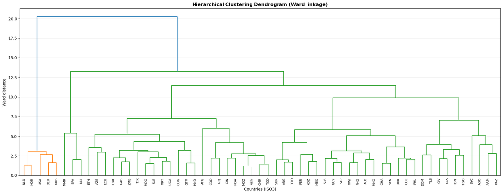

```
Hierarchical cluster sizes (k=2):
cluster_label
Non-Strong Governance    54
Strong Governance         5
Name: count, dtype: int64

Hierarchical cluster sizes (k=3):
cluster_label
Moderate Governance    51
Strong Governance       5
Weak Governance         3
Name: count, dtype: int64

--- Hierarchical cluster summary means (k=2) ---
```

| cluster | control_of_corruption_baseline_2019_2021 | government_effectiveness_baseline_2019_2021 | political_stability_baseline_2019_2021 | regulatory_quality_baseline_2019_2021 | rule_of_law_baseline_2019_2021 | voice_and_accountability_baseline_2019_2021 | delta_control_of_corruption | delta_government_effectiveness | delta_political_stability | delta_regulatory_quality | delta_rule_of_law | delta_voice_and_accountability |
| --- | --- | --- | --- | --- | --- | --- | --- | --- | --- | --- | --- | --- |
| 1 | 1.72 | 1.53 | 0.63 | 1.60 | 1.61 | 1.34 | -0.10 | -0.22 | -0.13 | -0.17 | -0.16 | -0.01 |
| 2 | -0.65 | -0.65 | -0.62 | -0.57 | -0.71 | -0.36 | 0.05 | 0.02 | -0.05 | -0.02 | -0.00 | -0.05 |

```
--- Hierarchical cluster summary means (k=3) ---
```

| cluster | control_of_corruption_baseline_2019_2021 | government_effectiveness_baseline_2019_2021 | political_stability_baseline_2019_2021 | regulatory_quality_baseline_2019_2021 | rule_of_law_baseline_2019_2021 | voice_and_accountability_baseline_2019_2021 | delta_control_of_corruption | delta_government_effectiveness | delta_political_stability | delta_regulatory_quality | delta_rule_of_law | delta_voice_and_accountability |
| --- | --- | --- | --- | --- | --- | --- | --- | --- | --- | --- | --- | --- |
| 1 | 1.72 | 1.53 | 0.63 | 1.60 | 1.61 | 1.34 | -0.10 | -0.22 | -0.13 | -0.17 | -0.16 | -0.01 |
| 2 | -0.58 | -1.05 | -1.79 | -0.65 | -0.87 | -0.66 | -0.21 | -0.29 | -0.92 | -0.17 | -0.30 | -0.76 |
| 3 | -0.66 | -0.63 | -0.55 | -0.56 | -0.70 | -0.34 | 0.06 | 0.04 | 0.00 | -0.01 | 0.02 | -0.01 |

```
Membership (Hierarchical, k=2):
```

|  | cluster_label | n | countries |
| --- | --- | --- | --- |
| 0 | Non-Strong Governance | 54 | AFG, AGO, ALB, ARG, ARM, AZE, BFA, CIV, CMR, COD, COG, COL, DOM, ECU, ETH, GAB, GHA, GIN, GTM, GUY, HND, IDN, IRQ, KAZ, KGZ, LBR, MDG, MEX, MLI, MMR, MNG, MOZ, MRT, MWI, NER, NGA, PER, PHL, PNG, SEN, … |
| 1 | Strong Governance | 5 | DEU, GBR, NLD, NOR, USA |

```
Membership (Hierarchical, k=3):
```

|  | cluster_label | n | countries |
| --- | --- | --- | --- |
| 0 | Moderate Governance | 51 | AFG, AGO, ALB, ARG, ARM, AZE, CIV, CMR, COD, COG, COL, DOM, ECU, ETH, GAB, GHA, GIN, GTM, GUY, HND, IDN, IRQ, KAZ, KGZ, LBR, MDG, MEX, MNG, MOZ, MRT, MWI, NER, NGA, PER, PHL, PNG, SEN, SLB, SLE, STP, … |
| 1 | Strong Governance | 5 | DEU, GBR, NLD, NOR, USA |
| 2 | Weak Governance | 3 | BFA, MLI, MMR |

```
Agreement table (k=2):
```

| hierarchical kmeans | Non-Strong Governance | Strong Governance |
| --- | --- | --- |
| Non-Strong Governance | 54 | 0 |
| Strong Governance | 0 | 5 |

```
Agreement table (k=3):
```

| hierarchical kmeans | Moderate Governance | Strong Governance | Weak Governance |
| --- | --- | --- | --- |
| Moderate Governance | 28 | 0 | 0 |
| Strong Governance | 0 | 5 | 0 |
| Weak Governance | 23 | 0 | 3 |

```python
# =====================================================
# VISUAL: Hierarchical Clustering (robustness check)
#   - Uses same standardized feature matrix as K-means (X_scaled)
#   - Shows:
#       (1) Dendrogram (Ward linkage)
#       (2) Cut-tree cluster labels for k=2 and k=3
#       (3) Compact membership tables (ISO3s)
# =====================================================

# -----------------------------------------------------
# 0) Safety checks
# -----------------------------------------------------
if "X" not in globals() or "X_scaled" not in globals():
    raise ValueError("Need X and X_scaled from the K-means block. Run previous visual first.")

# Ensure index is ISO3 codes
iso3_index = X.index.astype(str).str.upper().str.strip()

# -----------------------------------------------------
# 1) Fit hierarchical clustering (Ward linkage)
#    Ward is a strong default when using Euclidean distance on standardized data
# -----------------------------------------------------
Z = linkage(X_scaled, method="ward")  # Euclidean distance implied

# -----------------------------------------------------
# 2) Dendrogram
# -----------------------------------------------------
fig, ax = plt.subplots(figsize=(18, 7))

dendrogram(
    Z,
    labels=iso3_index.tolist(),
    leaf_rotation=90,
    leaf_font_size=8,
    ax=ax
)

ax.set_title(
    "Hierarchical Clustering Dendrogram (Ward linkage)",
    fontsize=12,
    fontweight="bold"
)
ax.set_xlabel("Countries (ISO3)")
ax.set_ylabel("Ward distance")
ax.grid(axis="y", alpha=0.25)

plt.tight_layout()
plt.show()

# -----------------------------------------------------
# 3) Extract cluster assignments for k = 2 and k = 3
# -----------------------------------------------------
hc_labels = {}
for k in [2, 3]:
    # fcluster returns cluster ids: 1..k
    hc_labels[k] = fcluster(Z, t=k, criterion="maxclust")

# Build DataFrames
hc2 = pd.DataFrame({"iso3c": iso3_index, "hc_cluster": hc_labels[2]}).set_index("iso3c")
hc3 = pd.DataFrame({"iso3c": iso3_index, "hc_cluster": hc_labels[3]}).set_index("iso3c")

# -----------------------------------------------------
# 4) Interpretable labels based on baseline governance level
# -----------------------------------------------------
baseline_cols = [c for c in X.columns if "baseline" in c]
if len(baseline_cols) == 0:
    raise ValueError("No baseline columns found in X (expected columns containing 'baseline').")

def label_by_baseline(cluster_series, baseline_cols, k):
    tmp = X.copy()
    tmp["cluster"] = cluster_series.values

    means = tmp.groupby("cluster")[baseline_cols].mean().mean(axis=1).sort_values()  # low -> high
    order = means.index.tolist()

    if k == 2:
        mapping = {order[0]: "Non-Strong Governance", order[1]: "Strong Governance"}
    elif k == 3:
        mapping = {order[0]: "Weak Governance", order[1]: "Moderate Governance", order[2]: "Strong Governance"}
    else:
        mapping = {cl: f"Cluster {cl}" for cl in order}

    return cluster_series.map(mapping)

hc2["cluster_label"] = label_by_baseline(hc2["hc_cluster"], baseline_cols, k=2)
hc3["cluster_label"] = label_by_baseline(hc3["hc_cluster"], baseline_cols, k=3)

print("\nHierarchical cluster sizes (k=2):")
print(hc2["cluster_label"].value_counts())

print("\nHierarchical cluster sizes (k=3):")
print(hc3["cluster_label"].value_counts())

# -----------------------------------------------------
# 5) Cluster summary means (same features as K-means)
# -----------------------------------------------------
def cluster_summary(cluster_series):
    tmp = X.copy()
    tmp["cluster"] = cluster_series.values
    return tmp.groupby("cluster")[X.columns].mean().round(2)

print("\n--- Hierarchical cluster summary means (k=2) ---")
display(cluster_summary(hc2["hc_cluster"]))

print("\n--- Hierarchical cluster summary means (k=3) ---")
display(cluster_summary(hc3["hc_cluster"]))

# -----------------------------------------------------
# 6) Membership tables (full ISO3 lists, wrapped)
# -----------------------------------------------------
def membership_table(cluster_df):
    out = (
        cluster_df.reset_index(names="iso3c")
                  .groupby("cluster_label", as_index=False)
                  .agg(
                      n=("iso3c", "count"),
                      countries=("iso3c", lambda s: ", ".join(sorted(s)))
                  )
                  .sort_values("n", ascending=False)
                  .reset_index(drop=True)
    )
    return out

print("\nMembership (Hierarchical, k=2):")
display(
    membership_table(hc2)
    .style
    .set_properties(
        subset=["countries"],
        **{"white-space": "normal", "max-width": "900px", "font-size": "10pt"}
    )
)

print("\nMembership (Hierarchical, k=3):")
display(
    membership_table(hc3)
    .style
    .set_properties(
        subset=["countries"],
        **{"white-space": "normal", "max-width": "900px", "font-size": "10pt"}
    )
)

# -----------------------------------------------------
# 7) Compare K-means vs Hierarchical assignments
# -----------------------------------------------------
if "results" in globals() and 2 in results and 3 in results:
    km2 = results[2].copy()
    km3 = results[3].copy()

    compare2 = (
        pd.DataFrame({"iso3c": X.index})
          .set_index("iso3c")
          .assign(kmeans=km2["cluster_label"].values, hierarchical=hc2["cluster_label"].values)
    )
    compare3 = (
        pd.DataFrame({"iso3c": X.index})
          .set_index("iso3c")
          .assign(kmeans=km3["cluster_label"].values, hierarchical=hc3["cluster_label"].values)
    )

    print("\nAgreement table (k=2):")
    display(pd.crosstab(compare2["kmeans"], compare2["hierarchical"]))

    print("\nAgreement table (k=3):")
    display(pd.crosstab(compare3["kmeans"], compare3["hierarchical"]))
```

The resulting dendrogram reinforces the conclusions drawn from K-means. A small group of countries—Germany, the United Kingdom, the Netherlands, Norway, and the United States—branches off from the rest of the sample at a very early stage, indicating a pronounced and stable separation in governance profiles. This visual structure closely mirrors the two-cluster solution identified earlier.

When the dendrogram is cut to produce two clusters, the hierarchical classification reproduces the K-means results exactly. The same five high-governance countries form a distinct cluster, while all remaining countries fall into a single lower-governance group. The perfect agreement between K-means and hierarchical clustering at k = 2 confirms that this division is not an artefact of the clustering algorithm, but rather reflects a fundamental structure in the data. As before, differences in baseline governance levels dominate this split, while changes over time remain comparatively small.

Imposing a three-cluster cut yields a different, but informative, refinement. Rather than dividing the lower-governance group evenly into weak and moderate regimes, hierarchical clustering isolates a very small subset of countries—Burkina Faso, Mali, and Myanmar—that exhibit exceptionally low baseline governance and unusually large deteriorations over time, particularly in political stability and voice and accountability. The remainder of the sample forms a broad intermediate cluster with more moderate baseline levels and relatively limited average change. This contrast suggests that, under hierarchical clustering, the most salient secondary distinction is between extreme outliers and the rest of the lower-governance countries, rather than a gradual governance gradient.

Taken together, the hierarchical results strengthen the overall interpretation of the analysis. The primary and most robust pattern across methods is a stark separation between a small set of very high-governance countries and the rest of the sample. Finer distinctions among lower-governance countries are more sensitive to the choice of clustering method and reflect either gradual differences in governance levels (as in K-means) or the presence of a small group of extreme cases (as in hierarchical clustering). This reinforces the conclusion that cross-country differences in governance are driven mainly by baseline capacity, with temporal changes playing a secondary and more uneven role.

### III.8 Resource Rents and Governance: Cross-Section vs Within-Country Effects

We next examine whether resource dependence is associated with governance outcomes, and whether this relationship reflects cross-country differences or within-country changes over time.

```python
# =====================================================
# REGRESSION MODEL:
#   wgi_mean ~ L1(total natural resource rents % GDP)
#   Models: Pooled, Country FE, Country+Year FE
#   SEs   : Clustered by country (iso3c)
# =====================================================

# -----------------------------
# 0) CONFIG
# -----------------------------
Y = "wgi_mean"
X_RENTS = "total_natural_resource_rents_pct_gdp"

USE_LAG = True
LAG_YEARS = 1

WINSORIZE = True
WINSOR_P = 0.01  # 1% tails

# -----------------------------
# 1) Prep + checks
# -----------------------------
needed = {"iso3c", "year", Y, X_RENTS}
missing = needed - set(merged_df.columns)
if missing:
    raise ValueError(f"merged_df missing required columns: {sorted(missing)}")

df = merged_df.loc[:, ["iso3c", "year", Y, X_RENTS]].copy()

df["iso3c"] = df["iso3c"].astype(str).str.upper().str.strip()
df["year"] = pd.to_numeric(df["year"], errors="coerce")

df[Y] = pd.to_numeric(df[Y], errors="coerce")
df[X_RENTS] = pd.to_numeric(df[X_RENTS], errors="coerce")

df = df.dropna(subset=["iso3c", "year", Y, X_RENTS]).copy()

# -----------------------------
# 2) winsorization
#    - We winsorize X_RENTS to reduce the influence of extreme outliers.
#    - Specifically, we cap values below the 1st percentile to the 1st percentile,
#    - and values above the 99th percentile to the 99th percentile.
#    - This preserves all observations (unlike trimming/dropping) but limits leverage from extremes.
# -----------------------------
def winsorize_series(s, p=0.01):
    lo = s.quantile(p)
    hi = s.quantile(1 - p)
    return s.clip(lower=lo, upper=hi)

if WINSORIZE:
    df[X_RENTS] = winsorize_series(df[X_RENTS], p=WINSOR_P)

# -----------------------------
# 3) lag
#    - We use a lag of total natural resource rents (% of GDP) to reduce simultaneity
#    - and reverse causality between resource rents and governance (WGI).
#    - Specifically, X at time t−1 is used to explain WGI at time t.
#
#    - This ensures temporal ordering: changes in resource rents precede changes in governance.
#    - The lag is computed within each country (iso3c) after sorting by year.
#
#    - Observations from the first available year per country become missing after lagging
#    - and are dropped from the regression sample.
# -----------------------------
if USE_LAG:
    df = df.sort_values(["iso3c", "year"])
    X = f"{X_RENTS}_L{LAG_YEARS}"
    df[X] = df.groupby("iso3c")[X_RENTS].shift(LAG_YEARS)
else:
    X = X_RENTS

df_reg = df.dropna(subset=[X]).copy()

print(
    f"N={df_reg.shape[0]} rows, "
    f"{df_reg['iso3c'].nunique()} countries, "
    f"years {int(df_reg['year'].min())}–{int(df_reg['year'].max())}"
)

# -----------------------------
# 4) Fit models (clustered SEs)
# We estimate three increasingly specifications:
#
# (1) Pooled OLS:
#     - Uses all country-year observations without fixed effects.
#     - Interprets the association using both between-country and within-country variation.
#
# (2) Country Fixed Effects (FE):
#     - Adds C(iso3c) to control for all time-invariant country characteristics
#     - Identification comes from within-country changes over time.
#
# (3) Two-Way Fixed Effects (TWFE = Country + Year FE):
#     - Adds both C(iso3c) and C(year).
#     - Controls for country-invariant global shocks/common trends in each year
#     - Identification comes from within-country deviations from year-specific averages.
#
# We cluster standard errors at the country level (iso3c) to allow arbitrary
# serial correlation and heteroskedasticity within countries over time.
# This is standard for panel data where errors may be correlated within unit.
# -----------------------------
f_pooled = f"{Y} ~ {X}"
f_ctyfe  = f"{Y} ~ {X} + C(iso3c)"
f_twfe   = f"{Y} ~ {X} + C(iso3c) + C(year)"

def fit_clustered(formula, data):
    return smf.ols(formula, data=data).fit(
        cov_type="cluster",
        cov_kwds={"groups": data["iso3c"]}
    )

m1 = fit_clustered(f_pooled, df_reg)
m2 = fit_clustered(f_ctyfe,  df_reg)
m3 = fit_clustered(f_twfe,   df_reg)

# -----------------------------
# 5) Output table
# -----------------------------
display(summary_col(
    [m1, m2, m3],
    stars=True,
    model_names=["Pooled OLS", "Country FE", "Country+Year FE"],
    info_dict={
        "N": lambda x: f"{int(x.nobs)}",
        "R2": lambda x: f"{x.rsquared:.3f}"
    }
))

# -----------------------------
# 6) coefficient readout
# -----------------------------
b1, se1 = m1.params.get(X, np.nan), m1.bse.get(X, np.nan)
b2, se2 = m2.params.get(X, np.nan), m2.bse.get(X, np.nan)
b3, se3 = m3.params.get(X, np.nan), m3.bse.get(X, np.nan)

print(f"\nMain coefficient on {X}:")
print(f"  Pooled OLS       : {b1:.4f} (SE {se1:.4f})")
print(f"  Country FE       : {b2:.4f} (SE {se2:.4f})")
print(f"  Country + Year FE: {b3:.4f} (SE {se3:.4f})")
```

```
N=354 rows, 59 countries, years 2016–2021
```

|  | Pooled OLS | Country FE | Country+Year FE |
| --- | --- | --- | --- |
| Intercept | -0.1600 | -1.6195*** | -1.6072*** |
|  | (0.1413) | (0.0007) | (0.0096) |
| total_natural_resource_rents_pct_gdp_L1 | -0.0293*** | 0.0004 | 0.0000 |
|  | (0.0099) | (0.0012) | (0.0013) |
| C(iso3c)[T.AGO] |  | 0.7004*** | 0.7094*** |
|  |  | (0.0273) | (0.0303) |
| C(iso3c)[T.ALB] |  | 1.5686*** | 1.5689*** |
|  |  | (0.0009) | (0.0010) |
| C(iso3c)[T.ARG] |  | 1.5425*** | 1.5428*** |
|  |  | (0.0010) | (0.0011) |
| C(iso3c)[T.ARM] |  | 1.4000*** | 1.4002*** |
|  |  | (0.0007) | (0.0007) |
| C(iso3c)[T.AZE] |  | 0.9111*** | 0.9183*** |
|  |  | (0.0217) | (0.0241) |
| C(iso3c)[T.BFA] |  | 1.1062*** | 1.1101*** |
|  |  | (0.0118) | (0.0131) |
| C(iso3c)[T.CIV] |  | 1.0454*** | 1.0464*** |
|  |  | (0.0029) | (0.0032) |
| C(iso3c)[T.CMR] |  | 0.5390*** | 0.5409*** |
|  |  | (0.0058) | (0.0065) |
| C(iso3c)[T.COD] |  | -0.0036 | 0.0035 |
|  |  | (0.0216) | (0.0240) |
| C(iso3c)[T.COG] |  | 0.5036*** | 0.5146*** |
|  |  | (0.0331) | (0.0368) |
| C(iso3c)[T.COL] |  | 1.4112*** | 1.4124*** |
|  |  | (0.0037) | (0.0041) |
| C(iso3c)[T.DEU] |  | 3.0542*** | 3.0540*** |
|  |  | (0.0006) | (0.0007) |
| C(iso3c)[T.DOM] |  | 1.4506*** | 1.4508*** |
|  |  | (0.0005) | (0.0005) |

[output cut: 104 more lines]

Standard errors in parentheses.  
* p<.1, ** p<.05, ***p<.01

```
Main coefficient on total_natural_resource_rents_pct_gdp_L1:
  Pooled OLS       : -0.0293 (SE 0.0099)
  Country FE       : 0.0004 (SE 0.0012)
  Country + Year FE: 0.0000 (SE 0.0013)
```

In the pooled OLS regression, total natural resource rents appear to “matter” in the expected direction. The coefficient on lagged rents is negative and statistically significant (≈ −0.029), which reproduces the familiar cross-country pattern: countries that rely more heavily on resource rents tend to have weaker governance on average. Read alone, this looks like a clean resource-curse relationship.

However, the fixed-effects models change the interpretation. Once country fixed effects are included (and then year fixed effects), the rents coefficient collapses to essentially zero. This implies that the pooled OLS association is driven primarily by between-country differences, not within-country variation over time. In other words, countries that are structurally more resource-dependent also tend to have persistently lower governance levels, but short-run changes in a country’s resource rents from 2016–2021 do not predict systematic changes in its governance score in the following year.

The broader message is that, over this short window, governance behaves like a slow-moving institutional characteristic, while resource rents behave like a volatile economic signal—and the two do not line up in a consistent year-to-year way once we compare countries to themselves. The “resource curse” shows up clearly as a cross-sectional pattern, but it does not translate into a detectable within-country dynamic effect in this period. This aligns with the PCA and clustering results: most separation in the data is driven by baseline governance capacity, not by short-run governance movements. In that sense, resource rents help explain differences between governance regimes, but they do not appear to generate consistent within-regime governance shifts over this short window.

### III.9 Robustness: Oil, Gas, and Mineral Rents

To test whether the aggregate relationship masks differences across resource types, we decompose total natural resource rents into oil, gas, and mineral rents and re-estimate the pooled and fixed-effects models.

```python
# =====================================================
# ROBUSTNESS CHECK:
#   rents components (oil/gas/mineral) instead of total rents
#   wgi_mean ~ L1(oil_rents) + L1(gas_rents) + L1(mineral_rents)
#   Models: Pooled, Country FE, Country+Year FE
#   SEs   : Clustered by country (iso3c)
# =====================================================

# -----------------------------
# 0) CONFIG
# -----------------------------
Y = "wgi_mean"
X_OIL = "oil_rents_pct_gdp"
X_GAS = "gas_rents_pct_gdp"
X_MIN = "mineral_rents_pct_gdp"

USE_LAG = True
LAG_YEARS = 1

WINSORIZE = True
WINSOR_P = 0.01  # 1% tails

# -----------------------------
# 1) Prep + checks
# -----------------------------
needed = {"iso3c", "year", Y, X_OIL, X_GAS, X_MIN}
missing = needed - set(merged_df.columns)
if missing:
    raise ValueError(f"merged_df missing required columns: {sorted(missing)}")

df = merged_df.loc[:, ["iso3c", "year", Y, X_OIL, X_GAS, X_MIN]].copy()

df["iso3c"] = df["iso3c"].astype(str).str.upper().str.strip()
df["year"] = pd.to_numeric(df["year"], errors="coerce")

for c in [Y, X_OIL, X_GAS, X_MIN]:
    df[c] = pd.to_numeric(df[c], errors="coerce")

df = df.dropna(subset=["iso3c", "year", Y]).copy()

# -----------------------------
# 2) winsorization
# -----------------------------
def winsorize_series(s, p=0.01):
    lo = s.quantile(p)
    hi = s.quantile(1 - p)
    return s.clip(lower=lo, upper=hi)

if WINSORIZE:
    for c in [X_OIL, X_GAS, X_MIN]:
        df[c] = winsorize_series(df[c], p=WINSOR_P)

# -----------------------------
# 3) lags
# -----------------------------
if USE_LAG:
    df = df.sort_values(["iso3c", "year"])
    X1 = f"{X_OIL}_L{LAG_YEARS}"
    X2 = f"{X_GAS}_L{LAG_YEARS}"
    X3 = f"{X_MIN}_L{LAG_YEARS}"

    df[X1] = df.groupby("iso3c")[X_OIL].shift(LAG_YEARS)
    df[X2] = df.groupby("iso3c")[X_GAS].shift(LAG_YEARS)
    df[X3] = df.groupby("iso3c")[X_MIN].shift(LAG_YEARS)
else:
    X1, X2, X3 = X_OIL, X_GAS, X_MIN

df_reg = df.dropna(subset=[X1, X2, X3]).copy()

print(
    f"N={df_reg.shape[0]} rows, "
    f"{df_reg['iso3c'].nunique()} countries, "
    f"years {int(df_reg['year'].min())}–{int(df_reg['year'].max())}"
)

# -----------------------------
# 4) Fit models (clustered SEs)
# -----------------------------
rhs = f"{X1} + {X2} + {X3}"

f_pooled = f"{Y} ~ {rhs}"
f_ctyfe  = f"{Y} ~ {rhs} + C(iso3c)"
f_twfe   = f"{Y} ~ {rhs} + C(iso3c) + C(year)"

def fit_clustered(formula, data):
    return smf.ols(formula, data=data).fit(
        cov_type="cluster",
        cov_kwds={"groups": data["iso3c"]}
    )

m1 = fit_clustered(f_pooled, df_reg)
m2 = fit_clustered(f_ctyfe,  df_reg)
m3 = fit_clustered(f_twfe,   df_reg)

# -----------------------------
# 5) Output table
# -----------------------------
display(summary_col(
    [m1, m2, m3],
    stars=True,
    model_names=["Pooled OLS", "Country FE", "Country+Year FE"],
    info_dict={
        "N": lambda x: f"{int(x.nobs)}",
        "R2": lambda x: f"{x.rsquared:.3f}"
    }
))

# -----------------------------
# 6) coefficient readout
# -----------------------------
def coef_line(model, name):
    b = model.params.get(name, np.nan)
    se = model.bse.get(name, np.nan)
    return f"{b:.4f} (SE {se:.4f})"

print("\nKey coefficients (lagged component rents):")
print(f"  {X1}: Pooled {coef_line(m1, X1)} | FE {coef_line(m2, X1)} | TWFE {coef_line(m3, X1)}")
print(f"  {X2}: Pooled {coef_line(m1, X2)} | FE {coef_line(m2, X2)} | TWFE {coef_line(m3, X2)}")
print(f"  {X3}: Pooled {coef_line(m1, X3)} | FE {coef_line(m2, X3)} | TWFE {coef_line(m3, X3)}")
```

```
N=406 rows, 58 countries, years 2016–2022
```

|  | Pooled OLS | Country FE | Country+Year FE |
| --- | --- | --- | --- |
| Intercept | -0.2645** | -1.6330*** | -1.6196*** |
|  | (0.1265) | (0.0000) | (0.0116) |
| oil_rents_pct_gdp_L1 | -0.0277*** | -0.0006 | -0.0006 |
|  | (0.0061) | (0.0021) | (0.0027) |
| gas_rents_pct_gdp_L1 | 0.0073 | -0.0103 | -0.0097 |
|  | (0.0052) | (0.0078) | (0.0082) |
| mineral_rents_pct_gdp_L1 | -0.0417* | -0.0030 | -0.0026 |
|  | (0.0229) | (0.0032) | (0.0033) |
| C(iso3c)[T.AGO] |  | 0.7624*** | 0.7609*** |
|  |  | (0.0499) | (0.0637) |
| C(iso3c)[T.ALB] |  | 1.5885*** | 1.5884*** |
|  |  | (0.0024) | (0.0031) |
| C(iso3c)[T.ARG] |  | 1.5370*** | 1.5367*** |
|  |  | (0.0032) | (0.0040) |
| C(iso3c)[T.ARM] |  | 1.4237*** | 1.4231*** |
|  |  | (0.0056) | (0.0058) |
| C(iso3c)[T.AZE] |  | 0.9777*** | 0.9748*** |
|  |  | (0.0458) | (0.0583) |
| C(iso3c)[T.BFA] |  | 1.1044*** | 1.1025*** |
|  |  | (0.0169) | (0.0175) |
| C(iso3c)[T.CIV] |  | 1.0929*** | 1.0924*** |
|  |  | (0.0033) | (0.0037) |
| C(iso3c)[T.CMR] |  | 0.5590*** | 0.5588*** |
|  |  | (0.0051) | (0.0066) |
| C(iso3c)[T.COD] |  | 0.0394* | 0.0370* |
|  |  | (0.0207) | (0.0217) |
| C(iso3c)[T.COG] |  | 0.5587*** | 0.5572*** |
|  |  | (0.0553) | (0.0704) |
| C(iso3c)[T.COL] |  | 1.4337*** | 1.4334*** |
|  |  | (0.0059) | (0.0076) |

[output cut: 108 more lines]

Standard errors in parentheses.  
* p<.1, ** p<.05, ***p<.01

```
Key coefficients (lagged component rents):
  oil_rents_pct_gdp_L1: Pooled -0.0277 (SE 0.0061) | FE -0.0006 (SE 0.0021) | TWFE -0.0006 (SE 0.0027)
  gas_rents_pct_gdp_L1: Pooled 0.0073 (SE 0.0052) | FE -0.0103 (SE 0.0078) | TWFE -0.0097 (SE 0.0082)
  mineral_rents_pct_gdp_L1: Pooled -0.0417 (SE 0.0229) | FE -0.0030 (SE 0.0032) | TWFE -0.0026 (SE 0.0033)
```

In the pooled OLS specification, the familiar cross-country “resource curse” pattern reappears, driven primarily by oil rents and, to a lesser extent, mineral rents. Countries that are more dependent on oil extraction tend to exhibit weaker average governance, while mineral rents display a negative but less precisely estimated association. Gas rents, by contrast, show no clear relationship with governance in the pooled model.

Once country fixed effects (and year fixed effects) are introduced, the coefficients on oil, gas, and mineral rents all collapse toward zero and lose statistical significance. This indicates that the negative pooled relationships are largely capturing persistent differences across countries rather than within-country responses over time. Even when resource rents are disaggregated by type, short-run changes in rent dependence within a country from 2016–2022 do not systematically predict changes in governance in the following year.

Taken together, these results reinforce the central conclusion of the analysis: the association between resource dependence and governance operates primarily through long-standing structural differences between countries, not through dynamic governance responses to year-to-year fluctuations in resource revenues. This finding is consistent with the PCA and clustering results, which highlight baseline governance capacity as the dominant source of cross-country variation.

### III.10 Robustness: Governance Changes Instead of Levels

As a further robustness check, we focus directly on short-run institutional dynamics by redefining the outcome variable as year-to-year changes in governance (ΔWGI).

```python
# =====================================================
# ROBUSTNESS CHECK:
#   Governance change on resource rents
#   Δwgi_mean = wgi_mean_t − wgi_mean_{t−1}
#   Δwgi_mean ~ L1(total natural resource rents % GDP)
#   Models: Pooled, Year FE, Country+Year FE
#   SEs   : Clustered by country (iso3c)
# =====================================================

# -----------------------------
# 0) CONFIG
# -----------------------------
Y = "wgi_mean"
X = "total_natural_resource_rents_pct_gdp"

USE_LAG = True
LAG_YEARS = 1

WINSORIZE = True
WINSOR_P = 0.01  # 1% tails

# -----------------------------
# 1) Prep + checks
# -----------------------------
needed = {"iso3c", "year", Y, X}
missing = needed - set(merged_df.columns)
if missing:
    raise ValueError(f"merged_df missing required columns: {sorted(missing)}")

df = merged_df.loc[:, ["iso3c", "year", Y, X]].copy()

df["iso3c"] = df["iso3c"].astype(str).str.upper().str.strip()
df["year"] = pd.to_numeric(df["year"], errors="coerce")

df[Y] = pd.to_numeric(df[Y], errors="coerce")
df[X] = pd.to_numeric(df[X], errors="coerce")

df = df.dropna(subset=["iso3c", "year", Y]).copy()

# -----------------------------
# 2) Construct ΔWGI
# -----------------------------
df = df.sort_values(["iso3c", "year"])
df["delta_wgi"] = df.groupby("iso3c")[Y].diff()

# -----------------------------
# 3) Winsorize rents
# -----------------------------
def winsorize_series(s, p=0.01):
    lo = s.quantile(p)
    hi = s.quantile(1 - p)
    return s.clip(lower=lo, upper=hi)

if WINSORIZE:
    df[X] = winsorize_series(df[X], p=WINSOR_P)

# -----------------------------
# 4) Lag rents
# -----------------------------
if USE_LAG:
    X_L1 = f"{X}_L{LAG_YEARS}"
    df[X_L1] = df.groupby("iso3c")[X].shift(LAG_YEARS)
else:
    X_L1 = X

df_reg = df.dropna(subset=["delta_wgi", X_L1]).copy()

print(
    f"N={df_reg.shape[0]} rows, "
    f"{df_reg['iso3c'].nunique()} countries, "
    f"years {int(df_reg['year'].min())}–{int(df_reg['year'].max())}"
)

# -----------------------------
# 5) Model formulas
# -----------------------------
f_pooled = f"delta_wgi ~ {X_L1}"
f_yearfe = f"delta_wgi ~ {X_L1} + C(year)"
f_twfe   = f"delta_wgi ~ {X_L1} + C(iso3c) + C(year)"

def fit_clustered(formula, data):
    return smf.ols(formula, data=data).fit(
        cov_type="cluster",
        cov_kwds={"groups": data["iso3c"]}
    )

m1 = fit_clustered(f_pooled, df_reg)
m2 = fit_clustered(f_yearfe, df_reg)
m3 = fit_clustered(f_twfe, df_reg)

# -----------------------------
# 6) Output table
# -----------------------------
display(summary_col(
    [m1, m2, m3],
    stars=True,
    model_names=["Pooled OLS", "Year FE", "Country+Year FE"],
    info_dict={
        "N": lambda x: f"{int(x.nobs)}",
        "R2": lambda x: f"{x.rsquared:.3f}"
    }
))

# -----------------------------
# 7) coefficient readout
# -----------------------------
def coef_line(model, name):
    b = model.params.get(name, np.nan)
    se = model.bse.get(name, np.nan)
    return f"{b:.4f} (SE {se:.4f})"

print("\nKey coefficient (lagged total resource rents):")
print(f"  Pooled OLS       : {coef_line(m1, X_L1)}")
print(f"  Year FE          : {coef_line(m2, X_L1)}")
print(f"  Country+Year FE  : {coef_line(m3, X_L1)}")
```

```
N=413 rows, 59 countries, years 2016–2022
```

|  | Pooled OLS | Year FE | Country+Year FE |
| --- | --- | --- | --- |
| Intercept | -0.0055 | 0.0123 | -0.0140 |
|  | (0.0046) | (0.0118) | (0.0121) |
| total_natural_resource_rents_pct_gdp_L1 | 0.0004 | 0.0004 | 0.0000 |
|  | (0.0003) | (0.0003) | (0.0013) |
| C(year)[T.2017] |  | -0.0249* | -0.0246* |
|  |  | (0.0133) | (0.0143) |
| C(year)[T.2018] |  | -0.0172 | -0.0164 |
|  |  | (0.0131) | (0.0142) |
| C(year)[T.2019] |  | -0.0164 | -0.0158 |
|  |  | (0.0139) | (0.0152) |
| C(year)[T.2020] |  | -0.0283** | -0.0281** |
|  |  | (0.0131) | (0.0141) |
| C(year)[T.2021] |  | -0.0191 | -0.0194 |
|  |  | (0.0191) | (0.0208) |
| C(year)[T.2022] |  | -0.0207 | -0.0191 |
|  |  | (0.0158) | (0.0165) |
| C(iso3c)[T.AGO] |  |  | 0.0597* |
|  |  |  | (0.0311) |
| C(iso3c)[T.ALB] |  |  | 0.0330*** |
|  |  |  | (0.0010) |
| C(iso3c)[T.ARG] |  |  | 0.0409*** |
|  |  |  | (0.0014) |
| C(iso3c)[T.ARM] |  |  | 0.0525*** |
|  |  |  | (0.0018) |
| C(iso3c)[T.AZE] |  |  | 0.0404 |
|  |  |  | (0.0258) |
| C(iso3c)[T.BFA] |  |  | -0.0134 |
|  |  |  | (0.0147) |
| C(iso3c)[T.CIV] |  |  | 0.0643*** |
|  |  |  | (0.0035) |

[output cut: 106 more lines]

Standard errors in parentheses.  
* p<.1, ** p<.05, ***p<.01

```
Key coefficient (lagged total resource rents):
  Pooled OLS       : 0.0004 (SE 0.0003)
  Year FE          : 0.0004 (SE 0.0003)
  Country+Year FE  : 0.0000 (SE 0.0013)
```

Across the pooled specification, the model with year fixed effects, and the model with both country and year fixed effects, the coefficient on lagged total natural resource rents is effectively zero and statistically insignificant. This indicates that increases or decreases in a country’s rent dependence from 2016–2022 do not reliably predict whether its governance improves or deteriorates in the following year. Instead, the year effects pick up modest common shocks—most visibly a negative shift around 2020—consistent with a period-wide governance deterioration during the pandemic, but these movements are not systematically linked to resource rents.

Overall, the Δ-governance results reinforce the central interpretation of the project: over this short window, governance changes are small and driven more by broad, shared dynamics than by fluctuations in resource rents, aligning with the PCA and clustering evidence that governance differences are dominated by slow-moving baseline institutional capacity rather than short-run revenue variation.

### III.11 Country Case Analysis by Governance Regime

To illustrate the patterns identified in the clustering and regression analyses, we conduct country case studies of Norway, Indonesia, and Burkina Faso, representing strong, moderate, and weak governance regimes across different regions.

```python
# Setup
merged_df["wgi_mean"] = merged_df[list(WGI_INDICATORS.values())].mean(axis=1)
all_countries = sorted(merged_df['iso3c'].unique())

country_choices = [
    (implementing_df[implementing_df['iso3'] == c]['label'].iloc[0] + f" ({c})", c)
    for c in all_countries
]

country_selector = SelectMultiple(
    options=country_choices,
    value=['NOR'],
    description='Countries:',
    rows=15,
    layout={'width': '400px'}
)

output = Output()

def update_plot(change):
    with output:
        clear_output(wait=True)

        selected = list(country_selector.value)
        if not selected:
            return

        dfv = merged_df[merged_df['iso3c'].isin(selected)]
        trend = dfv.groupby("year")[list(WGI_INDICATORS.values())].mean().reset_index()
        trend = pd.DataFrame({"year": list(range(2015, 2024))}).merge(trend, how="left")

        title = ', '.join(sorted(implementing_df[implementing_df['iso3'].isin(selected)]['label'].tolist()))

        # Plot
        fig, axes = plt.subplots(2, 3, figsize=(16, 8), sharex=True)
        axes = axes.flatten()

        titles = ["Control of Corruption", "Government Effectiveness", "Political Stability",
                  "Regulatory Quality", "Rule of Law", "Voice and Accountability"]

        for ax, col, title_text in zip(axes, list(WGI_INDICATORS.values()), titles):
            ax.axvspan(2015, 2019.99, alpha=0.4, color="#D9D9D9", lw=0)
            ax.axvspan(2020, 2021.99, alpha=0.4, color="#FFE066", lw=0)
            ax.axvspan(2022, 2023.99, alpha=0.4, color="#BFD7EA", lw=0)
            ax.plot(trend["year"], trend[col], marker="o", linewidth=2, color='steelblue')
            ax.axhline(0, linestyle="--", linewidth=1, alpha=0.3)
            ax.set_title(title_text, fontweight="bold", fontsize=11)
            ax.set_xlabel("Year", fontsize=9)
            ax.set_ylabel("Score", fontsize=9)
            ax.grid(True, alpha=0.25)
            ax.set_xticks(list(range(2015, 2024)))

        fig.legend(
            handles=[Patch(facecolor=c, alpha=0.4, label=l) for c, l in
                    [("#D9D9D9", "Pre-pandemic"), ("#FFE066", "Pandemic"), ("#BFD7EA", "Post-COVID")]],
            loc="lower center", ncol=3, bbox_to_anchor=(0.5, -0.02)
        )

        fig.suptitle(f"WGI Trends: {title} (2015–2023)", y=1.01, fontsize=15, fontweight="bold")
        plt.tight_layout(rect=[0, 0.06, 1, 1])
        plt.show()

        # Statistics (single print)
        pre_avg = trend[trend['year'].between(2015, 2019)][list(WGI_INDICATORS.values())].mean()
        post_avg = trend[trend['year'].between(2022, 2023)][list(WGI_INDICATORS.values())].mean()
        data_2023 = trend[trend['year'] == 2023].iloc[0]

        print(f"\n{'='*80}\nSummary Statistics: {title}\n{'='*80}")
        print("\nWGI Scores (2023):\n" + "-"*80)

        scores_2023 = [data_2023[k] for k in list(WGI_INDICATORS.values()) if pd.notna(data_2023[k])]
        for dim_key, dim_name in zip(list(WGI_INDICATORS.values()), titles):
            if pd.notna(data_2023[dim_key]):
                print(f"  {dim_name:30s}: {data_2023[dim_key]:+.3f}")

        if scores_2023:
            print(f"\n  WGI MEAN (2023): {np.mean(scores_2023):+.3f}")

        print("\nTOTAL CHANGE:\n" + "-"*80)
        for k, n in zip(list(WGI_INDICATORS.values()), titles):
            print(f"  {n:30s}: {post_avg[k] - pre_avg[k]:+.3f} {'↑' if post_avg[k] > pre_avg[k] else '↓'}")

        print("\nRESOURCE RENTS (2015-2021):\n" + "-"*80)
        rent_data = dfv[dfv['year'].between(2015, 2021)]
        for rc, rn in zip(['mineral_rents_pct_gdp', 'oil_rents_pct_gdp', 'gas_rents_pct_gdp', 'total_natural_resource_rents_pct_gdp'],
                          ['Mineral', 'Oil', 'Gas', 'Total']):
            if pd.notna(rent_data[rc].mean()):
                print(f"  {rn:30s}: {rent_data[rc].mean():6.2f}%")

country_selector.unobserve_all()
country_selector.observe(update_plot, names='value')

display(VBox([HTML("<b>Filter by country:</b> Select countries to compare (updates automatically)"), country_selector, output]))

update_plot(None)
```

```
VBox(children=(HTML(value='<b>Filter by country:</b> Select countries to compare (updates automatically)'), Se…
```

### Case 1: Norway (Strong Governance, Europe)

Norway is the single largest producer of oil and gas in Europe owing to its vast production in the North Sea dating back to the late 1960s. Its resource dependence was at around 10% in 2021 and averaged about 6% from 2015–2021. Despite this modest resource dependence, the country has evaded the resource curse and sustained high quality of governance. With a WGI mean of +1.669 in 2023, Norway represents the strong governance cluster. It scored highest in the control of corruption and rule of law indicators in the same year. The country recorded noticeable dips in the political stability (−0.271) and rule of law (−0.165) indicators while still maintaining high and positive scores in these indicators.

Overall, the country has maintained positive governance scores across all dimensions despite the presence of significant resource revenues. The country has managed to diversify its economy, invest in quality institutions, and achieve high human capital development. Despite being a small country, Norway currently manages the world's largest sovereign wealth fund, funded primarily by its resource revenues.

The case of Norway reinforces the findings of our analysis which demonstrate that resource dependence has little to no effect on the trajectory of governance outcomes of EITI countries. More importantly, it suggests that pre-existing institutional quality determines future governance outcomes rather than resource dependence. The country illustrates that the resource curse is a product of poor institutional quality and institutional lock-in, not resource dependence alone.

### Case 2: Indonesia (Moderate Governance, Asia)

Indonesia is rich in mineral, coal, oil, and gas resources. Despite this, the country's economy is relatively diversified with average natural resource rents as a percentage of GDP averaging 3.41% from 2015–2021. Resource dependence increased to about 5% in 2021 at a time when demand for its minerals increased amidst the energy transition. With moderate resource dependence, Indonesia saw mixed results in its governance trajectory.

The country represents the moderate governance cluster. Its mean WGI during the 2015–2019 period was −0.196. The country's governance trajectory showed improvement with a positive change of 0.162 when comparing the previous period and the post-COVID period of 2022–2023. The country saw major improvements in three governance indicators: regulatory quality, government effectiveness, and rule of law. However, the country has also seen stagnation in the control of corruption indicator and a decline in the voice and accountability indicator, which are critical for ensuring that vast resource revenues benefit its citizens.

Indonesia's case illustrates the institutions hypothesis of Acemoglu and Robinson (2012), which explains that elites are incentivized to invest in improving specific aspects of institutional and governance quality to attract investors and economic growth in order to sustain and secure more rents. However, the selective improvement in Indonesia—where regulatory quality and government effectiveness improved while voice and accountability declined—suggests that institutional investment may be driven by elite interests in facilitating extraction rather than genuine governance reform.

### Case 3: Burkina Faso (Weak Governance, Africa)

Burkina Faso is among the most resource-dependent countries in Africa with natural resource rents as a percentage of GDP at around 20% in 2021. This is driven mainly by the growth of its mining sector. The country's high resource dependence and governance trajectory represent a textbook case of the resource curse.

The overall WGI mean of Burkina Faso in 2023 was −0.845. The country scored lowest in political stability and voice and accountability during the same year following the two coups that occurred the previous year. It also plunged the most in these two governance indicators when comparing the pre-COVID and post-COVID periods while recording only modest improvement in the control of corruption indicator.

Despite the recent boom in its mineral sector, Burkina Faso's quality of governance has deteriorated, aligning its case more closely with the rent-seeking theory of Krueger (1974). In this model, rent-seeking behavior of political and economic elites coincides with and reinforces poor governance in order to secure their share from resource rents. Rather than incentivizing institutional investment, rising resource rents appear to have intensified elite competition for control of concentrated mineral wealth.

## IV. Conclusion

This project examined whether reliance on natural resource revenues is associated with changes in governance among EITI-implementing countries, with particular attention to the period surrounding the global energy transition. Using descriptive analysis, clustering techniques, and panel regressions, we find limited evidence that changes in resource dependence are followed by short-run improvements in governance.

Across the descriptive results, a consistent pattern emerges: governance outcomes are highly persistent. Average governance levels change little over time, the six WGI dimensions move closely together, and cross-country differences are much larger than year-to-year variation within countries. The PCA and clustering analyses reinforce this view, showing that countries tend to fall into stable governance regimes — strong, moderate, or weak — with relatively little movement between them during the period studied.

The regression results help clarify how this persistence relates to natural resource dependence. In pooled regressions, higher resource rents are associated with weaker governance, replicating a familiar cross-country “resource curse” pattern. However, once country fixed effects are introduced, this relationship disappears. Within countries, changes in total natural resource rents—and in oil, gas, or mineral rents separately—do not predict subsequent changes in governance. This result is robust to alternative specifications, revenue measures, and to modeling governance in first differences rather than levels.

Across the three countries analyzed, resource dependence increased in recent years in response to the growing demand for minerals amidst the energy transition and the spike in oil and gas prices during the pandemic. Governance indicators changed before and after the pandemic for all cases, with Burkina Faso deteriorating the most while Indonesia recorded a slight uptick in overall governance quality. Crucially, governance regimes have deteriorated in some aspects or remained stable across the study period despite the economic incentives and short-run resource booms that accompany the energy transition. The three cases suggest that institutional and governance quality plays a pivotal role in managing a country's natural resources and ensuring they lead to prosperity.

Taken together, these findings suggest that the resource curse observed in cross-section reflects long-standing structural differences between countries, rather than a dynamic process through which short-run revenue fluctuations translate into institutional change. Over the 2016–2022 period, governance behaves like a slow-moving characteristic, while resource rents are volatile. The two do not line up in a consistent year-to-year way once countries are compared to themselves.

This does not imply that natural resources or transparency initiatives such as the EITI are irrelevant for governance. Rather, it points to the limits of expecting revenue changes alone—whether from declining fossil fuels or rising mineral demand—to drive institutional improvement in the short run. Governance appears to be shaped more by deeper features of political and administrative capacity than by temporary shifts in resource income. To close this gap, international interventions such as the EITI should also address institutional quality and keep rent-seeking behavior in check. Without addressing underlying elite incentives and institutional capacity, transparency initiatives alone cannot overcome path-dependent governance regimes. **Overall, the evidence in this paper suggests that improving governance in resource-rich countries is likely to require sustained institutional reforms, rather than relying on changes in the composition or level of resource revenues alone.**

## V. References

Acemoglu, D., & Robinson, J. A. (2012). Why nations fail: The origins of power, prosperity, and poverty. Crown Business.

Extractive Industries Transparency Initiative (EITI). (2024). EITI API v2.0. Retrieved from https://eiti.org/api

Kaufmann, D., Kraay, A., & Mastruzzi, M. (2011). The Worldwide Governance Indicators: Methodology and analytical issues. World Bank Policy Research Working Paper, 5430.

Krueger, A. O. (1974). The political economy of the rent-seeking society. American Economic Review, 64(3), 291–303.

Ross, M. L. (2012). The oil curse: How petroleum wealth shapes the development of nations. Princeton University Press.

Sachs, J. D., & Warner, A. M. (1995). Natural resource abundance and economic growth. NBER Working Paper 5398.

World Bank. (2024). World Bank API for World Development Indicators. Accessed via wbgapi Python package. Retrieved from https://databank.worldbank.org/source/world-development-indicators

World Bank. (2024). Worldwide Governance Indicators (WGI). Accessed via wbgapi Python package. Retrieved from https://www.worldbank.org/en/publication/worldwide-governance-indicators